# RETRAUCI - Ultimate validation: preprocessing

2026-10-27

```r
library(dplyr)
library(lubridate)
raw_data <- read.csv2(
  "../retrauci_abril_2026.csv",
  stringsAsFactors = TRUE
)

#summary(raw_data)
```

```r
# ============================================================
# TABLE OF EMPTY CELLS, LITERAL "NAS" VALUES, AND VALID VALUES
# FOR ALL VARIABLES
# ============================================================

missingness_summary <- do.call(
  rbind,
  lapply(names(raw_data), function(variable) {

    # Temporarily convert to text without modifying the original data frame
    x <- trimws(as.character(raw_data[[variable]]))

    total_n <- length(x)

    # Empty Excel cells are usually imported as NA.
    # This also includes empty strings or values containing only spaces.
    is_empty <- is.na(x) | (!is.na(x) & x == "")

    # Literal "NAS" text, case-insensitive
    is_literal_nas <- !is.na(x) & toupper(x) == "NAS"

    # Values that are neither empty nor "NAS"
    is_valid <- !is_empty & !is_literal_nas

    data.frame(
      variable = variable,

      n_empty = sum(is_empty),
      pct_empty = round(
        100 * sum(is_empty) / total_n,
        2
      ),

      n_literal_nas = sum(is_literal_nas),
      pct_literal_nas = round(
        100 * sum(is_literal_nas) / total_n,
        2
      ),

      n_empty_or_nas = sum(is_empty | is_literal_nas),
      pct_empty_or_nas = round(
        100 * sum(is_empty | is_literal_nas) / total_n,
        2
      ),

      stringsAsFactors = FALSE
    )
  })
)

# Remove row names
rownames(missingness_summary) <- NULL

# Sort from highest to lowest percentage of empty cells plus NAS values
missingness_summary <- missingness_summary[
  order(
    -missingness_summary$pct_empty_or_nas,
    missingness_summary$variable
  ),
]

# Open the complete table in RStudio
View(missingness_summary)
```

# 1. Convert dates/times

```
##        fecha_trauma      fecha_alta_uci fecha_alta_hospital
##                   9                 190                 233
```

```
## hora_trauma
##           9
```

# 2. Convert numeric variables

```
##                edad hematocrito_inicial               fr_ph              pto_fr
##                 208                   1                  44                  44
##               rts_t                 rts                  ps            dias_uci
##                  44               16826                 252                 190
##       dias_hospital         rscore_edad      rscore_pupilas          retrascore
##                 232                 208                  45                 252
```

# 3. Candidate cohort based on the RETRASCORE paper

The cohort is constructed before the subsequent exclusions based on `edad` and `sdmo`. Following the paper, the only exclusion criterion applied here is an unavailable in-hospital mortality outcome. Missing predictor values are retained so they can be described and a complete-case analysis or imputation can be chosen later.

Operationalization decisions:

- ATLS-based management is a feature of the registry protocol, and no patient-level variable is available for use as a filter.
- In-hospital mortality combines `evolucion_uci` and `evolucion_hospitalaria`, because patients who die in the ICU generally do not have the hospital outcome field completed.
- The analytical outcome is `mortality_30d`: deaths within 30 days of trauma are coded as 1; live hospital discharges and deaths after day 30 are coded as 0. Deceased patients without a valid date retain an unknown outcome.
- `triss_death_probability` is calculated as `1 - ps/100`, because `ps` is stored as a survival percentage ranging from 0 to 100.
- Medical prehospital care is defined as `uvi movil` or `helicoptero`; the categories `no medicalizada`, `sin atencion prehospitalaria`, and `soporte vital enfermeria` form the reference group.
- Hemodynamic failure is approximated by `shock` or `shock refractario` in `situacion_hemodinamica`; respiratory failure is defined as PaO2/FiO2 less than or equal to 200 in `adrs`.
- `situacion_hemodinamica`, `adrs`, `coagulopatia`, `vmec_dico`, and `hemorragia_masiva` are assumed to represent the first 24 hours, as defined in the registry. The export has no timestamp that allows this to be verified for each patient.
- mais1-mais6 are used directly according to the current code mapping. In these fields, 0, an empty cell, NA, na, or NAS all mean that no lesion is present in that anatomical region and are therefore coded as 0.

```r
# Helper functions ---------------------------------------------------------

clean_text <- function(x) {
  x <- tolower(trimws(as.character(x)))
  x[x %in% c("", "na", "nas")] <- NA_character_
  x
}

clean_number <- function(x) {
  x <- trimws(as.character(x))
  x[x %in% c("", "NA", "NAS")] <- NA_character_
  suppressWarnings(as.numeric(gsub(",", ".", x)))
}

# In-hospital outcome. Patients who die in the ICU generally have an empty
# hospital outcome, so both outcome fields are combined.
clean_icu_outcome <- clean_text(raw_data$evolucion_uci)
clean_hospital_outcome <- clean_text(raw_data$evolucion_hospitalaria)

in_hospital_mortality <- case_when(
  clean_icu_outcome %in% c("exitus", "exitus y donacion") ~ 1L,
  clean_hospital_outcome %in% c(
    "exitus", "exitus y donacion"
  ) ~ 1L,
  clean_hospital_outcome == "alta" ~ 0L,
  TRUE ~ NA_integer_
)

# Primary outcome from the paper: mortality within 30 days of trauma.
# fecha_alta_uci is used for ICU deaths and fecha_alta_hospital for deaths
# after ICU discharge. fecha_exitus is used as a fallback.
icu_death <- clean_icu_outcome %in% c(
  "exitus", "exitus y donacion"
)
hospital_death <- clean_hospital_outcome %in% c(
  "exitus", "exitus y donacion"
)

death_date <- as.POSIXct(
  rep(NA_real_, nrow(raw_data)),
  origin = "1970-01-01",
  tz = "UTC"
)
death_date[icu_death] <- raw_data$fecha_alta_uci[icu_death]
death_date[hospital_death] <- raw_data$fecha_alta_hospital[
  hospital_death
]

use_recorded_death_date <- in_hospital_mortality == 1 &
  is.na(death_date) & !is.na(raw_data$fecha_exitus)
use_recorded_death_date[is.na(use_recorded_death_date)] <- FALSE
death_date[use_recorded_death_date] <- raw_data$fecha_exitus[use_recorded_death_date]

days_to_death <- as.numeric(
  difftime(death_date, raw_data$fecha_trauma, units = "days")
)
valid_death_date <- !is.na(days_to_death) & days_to_death >= 0

# Survival beyond day 30 is considered 30-day survival even if the patient
# dies later; these later deaths are not excluded.
mortality_30d <- case_when(
  in_hospital_mortality == 0 ~ 0L,
  in_hospital_mortality == 1 &
    valid_death_date & days_to_death <= 30 ~ 1L,
  in_hospital_mortality == 1 &
    valid_death_date & days_to_death > 30 ~ 0L,
  TRUE ~ NA_integer_
)

# Comparators used in the paper.
icu_length_of_stay_days <- clean_number(raw_data$dias_uci)
triss_survival_pct <- clean_number(raw_data$ps)
triss_death_probability <- ifelse(
  !is.na(triss_survival_pct) & triss_survival_pct >= 0 & triss_survival_pct <= 100,
  1 - triss_survival_pct / 100,
  NA_real_
)

# Patient-related variables -----------------------------------------------

clean_sex <- clean_text(raw_data$genero)
male <- case_when(
  clean_sex == "masculino" ~ 1L,
  clean_sex == "femenino" ~ 0L,
  TRUE ~ NA_integer_
)

age <- clean_number(raw_data$edad)
age_category <- cut(
  age,
  breaks = c(-Inf, 49, 65, 75, Inf),
  labels = c("<50", "50-65", "66-75", ">75"),
  right = TRUE
)

clean_antiplatelet <- clean_text(raw_data$antiagregado)
clean_vka <- clean_text(raw_data$dicumarinicos)
clean_doac <- clean_text(raw_data$acod)

preinjury_antithrombotic <- case_when(
  clean_antiplatelet == "si" |
    clean_vka == "si" |
    clean_doac == "si" ~ 1L,
  clean_antiplatelet == "no" &
    clean_vka == "no" &
    clean_doac == "no" ~ 0L,
  TRUE ~ NA_integer_
)

# Prehospital variables ----------------------------------------------------

clean_prehospital_care <- clean_text(raw_data$atencion_prehospitalaria)
physician_prehospital_care <- case_when(
  clean_prehospital_care %in% c("uvi movil", "helicoptero") ~ 1L,
  clean_prehospital_care %in% c(
    "no medicalizada", "sin atencion prehospitalaria",
    "soporte vital enfermeria"
  ) ~ 0L,
  TRUE ~ NA_integer_
)

clean_prehospital_intubation <- clean_text(raw_data$iot_prehospitalaria)
prehospital_intubation <- case_when(
  clean_prehospital_intubation %in% c(
    "si", "si, con empleo de dispositivos de apoyo"
  ) ~ 1L,
  clean_prehospital_intubation == "no" ~ 0L,
  TRUE ~ NA_integer_
)

clean_trauma_type <- clean_text(raw_data$tipo_trauma)
penetrating_trauma <- case_when(
  clean_trauma_type == "penetrante" ~ 1L,
  clean_trauma_type == "contuso" ~ 0L,
  TRUE ~ NA_integer_
)

clean_mechanism <- clean_text(raw_data$mecanismo)
# Requested grouping: other and unknown form a single category.
# Empty values remain NA and are not included in this category.
clean_mechanism[clean_mechanism %in% c(
  "otro", "otros", "desconocido"
)] <- "otros/desconocido"
clean_intent <- clean_text(raw_data$intencionalidad)

injury_type <- factor(
  case_when(
    clean_intent == "no intencional : trafico" ~
      "Road Traffic accident",
    clean_intent == "no intencional : caida" ~ "Fall",
    clean_intent == "no intencional : laboral" ~
      "Occupational accident",
    clean_intent == "no intencional : deportivo" ~
      "Sport related",
    clean_intent == "intencionado : agresion" ~ "Assault",
    clean_intent == "intencionado : autolisis" ~ "Self-injury",
    clean_intent == "desconocido" ~ "Unknown",
    clean_intent == "no intencional : otras actividades" ~
      "Other",
    TRUE ~ NA_character_
  ),
  levels = c(
    "Road Traffic accident", "Fall", "Occupational accident",
    "Sport related", "Assault", "Self-injury", "Unknown", "Other"
  )
)

# Every patient whose intent is self-injury (autolysis) is high risk, whatever
# the actual mechanism of the injury.
high_risk_mechanism <- case_when(
  clean_intent == "intencionado : autolisis" ~ 1L,
  clean_mechanism %in% c(
    "arma de fuego", "atropello", "caida accidental", "otros/desconocido"
  ) ~ 1L,
  !is.na(clean_mechanism) & clean_mechanism != "precipitacion" ~ 0L,
  clean_mechanism == "precipitacion" &
    !is.na(clean_intent) ~ 0L,
  TRUE ~ NA_integer_
)

# Self-injury as an independent binary variable (1 = self-injury, 0 = any other
# recorded intentionality, including unknown intentionality, which is not
# documented as self-injury). Empty intentionality remains missing.
self_injury <- case_when(
  clean_intent == "intencionado : autolisis" ~ 1L,
  !is.na(clean_intent) ~ 0L,
  TRUE ~ NA_integer_
)
```

```r
# Physiological variables --------------------------------------------------

clean_pupils <- clean_text(raw_data$pupilas_ingreso)
pupil_category <- factor(
  case_when(
    clean_pupils == "sin alteraciones" ~ "normal",
    clean_pupils == "midriasis unilateral" ~ "midriasis unilateral",
    clean_pupils == "midriasis bilatera" ~ "midriasis bilateral",
    TRUE ~ NA_character_
  ),
  levels = c("normal", "midriasis unilateral", "midriasis bilateral")
)

gcs_total <- clean_number(raw_data$gcs_total_introducido)
gcs_le_8 <- ifelse(
  is.na(gcs_total), NA_integer_, as.integer(gcs_total <= 8)
)

# Anatomical variables -----------------------------------------------------
# RETRAUCI regional MAIS variables are used directly:
# mais1 head, mais2 upper extremity, mais3 thorax, mais4 abdomen,
# mais5 lower extremity (including pelvis; see the pelvis split below), and
# mais6 external/thermal injuries.
# In this export, 0, an empty MAIS cell, NA, na, and NAS all mean that no injury
# is present in that region and are coded as 0. Other non-numeric values or
# values outside the AIS 0-6 range are retained as missing.

convert_regional_mais <- function(x) {
  text_value <- trimws(as.character(x))
  is_empty <- is.na(text_value) | text_value == "" |
    toupper(text_value) %in% c("NA", "NAS")
  result <- suppressWarnings(as.numeric(gsub(",", ".", text_value)))
  result[is_empty] <- 0
  result[!is.na(result) & !(result %in% 0:6)] <- NA_real_
  result
}

dichotomize_mais <- function(x) {
  ifelse(is.na(x), NA_integer_, as.integer(x >= 3))
}

# Severity of each anatomical region as a Yes/No variable: "Yes" when the
# regional AIS is 4 or higher, "No" when it is 3 or lower (including 0 = no
# injury in the region). "No" is the reference category.
categorize_mais <- function(x) {
  factor(
    case_when(
      is.na(x) ~ NA_character_,
      x >= 4 ~ "Yes",
      x <= 3 ~ "No"
    ),
    levels = c("No", "Yes")
  )
}

# Regional AIS values -------------------------------------------------------

head_ais <- convert_regional_mais(raw_data$mais1)
upper_extremity_ais <- convert_regional_mais(raw_data$mais2)
thorax_ais <- convert_regional_mais(raw_data$mais3)
abdomen_ais <- convert_regional_mais(raw_data$mais4)
lower_extremity_incl_pelvis_ais <- convert_regional_mais(raw_data$mais5)
external_ais <- convert_regional_mais(raw_data$mais6)

# Pelvis and lower extremity are analysed separately. In the AIS 2005 coding
# used by the registry, region 8 (lower extremity) includes the pelvis. Pelvic
# lesions are those whose AIS code (lesion_X_ais) starts with 8561 (pelvic ring)
# or 8562 (acetabulum). The text in lesion_X_nombre is a generic menu label and
# is NOT used to identify the pelvis.
# - pelvis_ais: maximum AIS severity among pelvic lesions (0 if none).
# - lower_extremity_ais: maximum AIS severity among the remaining region-8
#   lesions (pelvis excluded).
# Patients with no region-8 lesion detail in lesion_X_* cannot be split, so for
# them the total lower-extremity MAIS (mais5) is kept as lower extremity and
# pelvis_ais is 0. Their number is reported in the summary table below.
lesion_indices <- 0:31
lesion_region_columns <- paste0("lesion_", lesion_indices, "_region_ais")
lesion_severity_columns <- paste0("lesion_", lesion_indices, "_gravedad")
lesion_code_columns <- paste0("lesion_", lesion_indices, "_ais")

missing_lesion_columns <- setdiff(
  c(lesion_region_columns, lesion_severity_columns, lesion_code_columns),
  names(raw_data)
)
if (length(missing_lesion_columns) > 0L) {
  stop(
    "Missing lesion columns: ",
    paste(missing_lesion_columns, collapse = ", ")
  )
}

lesion_region <- sapply(raw_data[lesion_region_columns], clean_number)
lesion_severity <- sapply(raw_data[lesion_severity_columns], clean_number)
lesion_code_prefix <- sapply(
  raw_data[lesion_code_columns],
  function(x) substr(trimws(as.character(x)), 1, 4)
)
lesion_severity[!(lesion_severity %in% 1:6)] <- NA_real_

is_lower_limb_lesion <- lesion_region == 8
is_lower_limb_lesion[is.na(is_lower_limb_lesion)] <- FALSE
is_pelvic_lesion <- is_lower_limb_lesion &
  matrix(
    lesion_code_prefix %in% c("8561", "8562"),
    nrow = nrow(lesion_code_prefix)
  )
is_nonpelvic_lower_limb_lesion <- is_lower_limb_lesion & !is_pelvic_lesion

max_lesion_severity <- function(selected_lesions) {
  severity <- ifelse(selected_lesions, lesion_severity, 0)
  result <- apply(severity, 1, max, na.rm = TRUE)
  # A selected lesion without a valid severity leaves the maximum unknown.
  result[rowSums(selected_lesions & is.na(lesion_severity)) > 0] <- NA_real_
  result
}

has_lower_limb_detail <- rowSums(is_lower_limb_lesion) > 0
pelvis_ais <- max_lesion_severity(is_pelvic_lesion)
lower_extremity_ais <- ifelse(
  has_lower_limb_detail,
  max_lesion_severity(is_nonpelvic_lower_limb_lesion),
  lower_extremity_incl_pelvis_ais
)

# Organ failures within the first 24 hours --------------------------------

clean_hemodynamic_status <- clean_text(raw_data$situacion_hemodinamica)
hemodynamic_failure <- case_when(
  clean_hemodynamic_status %in% c("shock", "shock refractario") ~ 1L,
  clean_hemodynamic_status %in% c(
    "estable", "inestable remonta con volumen"
  ) ~ 0L,
  TRUE ~ NA_integer_
)

clean_respiratory_status <- clean_text(raw_data$adrs)
respiratory_failure <- case_when(
  clean_respiratory_status %in% c("<100", "101-200") ~ 1L,
  clean_respiratory_status %in% c("no", "201 -300", "> 300") ~ 0L,
  TRUE ~ NA_integer_
)

clean_coagulopathy <- clean_text(raw_data$coagulopatia)
coagulopathy_24h <- case_when(
  clean_coagulopathy == "si" ~ 1L,
  clean_coagulopathy == "no" ~ 0L,
  TRUE ~ NA_integer_
)

# Treatments within the first 24 hours ------------------------------------

clean_mechanical_ventilation <- clean_text(raw_data$vmec_dico)
mechanical_ventilation <- case_when(
  clean_mechanical_ventilation == "si" ~ 1L,
  clean_mechanical_ventilation == "no" ~ 0L,
  TRUE ~ NA_integer_
)

clean_massive_hemorrhage <- clean_text(raw_data$hemorragia_masiva)
massive_hemorrhage <- case_when(
  clean_massive_hemorrhage == "si" ~ 1L,
  clean_massive_hemorrhage == "no" ~ 0L,
  TRUE ~ NA_integer_
)
```

```r
# Final cohort -------------------------------------------------------------

retrascore_cohort <- data.frame(
  row_id = seq_len(nrow(raw_data)),
  medical_record = raw_data$historia,
  registry_record = raw_data$registro,
  hospital = raw_data$hospital,
  trauma_year = year(raw_data$fecha_trauma),
  in_hospital_mortality = in_hospital_mortality,
  mortality_30d = mortality_30d,
  days_to_death = days_to_death,
  icu_length_of_stay_days = icu_length_of_stay_days,
  triss_death_probability = triss_death_probability,
  male = male,
  age = age,
  age_category = age_category,
  preinjury_antithrombotic = preinjury_antithrombotic,
  physician_prehospital_care = physician_prehospital_care,
  prehospital_intubation = prehospital_intubation,
  penetrating_trauma = penetrating_trauma,
  injury_type = injury_type,
  grouped_mechanism = clean_mechanism,
  high_risk_mechanism = high_risk_mechanism,
  self_injury = self_injury,
  pupils = pupil_category,
  gcs_total = gcs_total,
  gcs_le_8 = gcs_le_8,
  head_ais = head_ais,
  head_mais = dichotomize_mais(head_ais),
  head_mais_group = categorize_mais(head_ais),
  thorax_ais = thorax_ais,
  thorax_mais = dichotomize_mais(thorax_ais),
  thorax_mais_group = categorize_mais(thorax_ais),
  abdomen_ais = abdomen_ais,
  abdomen_mais = dichotomize_mais(abdomen_ais),
  abdomen_mais_group = categorize_mais(abdomen_ais),
  upper_extremity_ais = upper_extremity_ais,
  upper_extremity_mais = dichotomize_mais(upper_extremity_ais),
  upper_extremity_mais_group = categorize_mais(upper_extremity_ais),
  lower_extremity_incl_pelvis_ais = lower_extremity_incl_pelvis_ais,
  lower_extremity_incl_pelvis_mais_group = categorize_mais(lower_extremity_incl_pelvis_ais),
  lower_extremity_ais = lower_extremity_ais,
  lower_extremity_mais = dichotomize_mais(lower_extremity_ais),
  pelvis_ais = pelvis_ais,
  pelvis_mais = dichotomize_mais(pelvis_ais),
  external_ais = external_ais,
  external_mais = dichotomize_mais(external_ais),
  external_mais_group = categorize_mais(external_ais),
  hemodynamic_failure = hemodynamic_failure,
  respiratory_failure = respiratory_failure,
  coagulopathy_24h = coagulopathy_24h,
  mechanical_ventilation = mechanical_ventilation,
  massive_hemorrhage = massive_hemorrhage
)

initial_n <- nrow(retrascore_cohort)
unknown_outcome_n <- sum(
  is.na(retrascore_cohort$in_hospital_mortality)
)

retrascore_cohort <- retrascore_cohort %>%
  filter(!is.na(in_hospital_mortality))

cohort_flow <- data.frame(
  stage = c(
    "Initial records",
    "Excluded: unknown in-hospital mortality",
    "RETRASCORE cohort"
  ),
  n = c(initial_n, unknown_outcome_n, nrow(retrascore_cohort))
)

cohort_flow
```

```
##                                     stage     n
## 1                         Initial records 19035
## 2 Excluded: unknown in-hospital mortality  1110
## 3                       RETRASCORE cohort 17925
```

```r
table(retrascore_cohort$mortality_30d, useNA = "ifany")
```

```
##
##     0     1  <NA>
## 15703  2211    11
```

```r
outcome_30d_summary <- data.frame(
  measure = c(
    "Eligible cohort",
    "Evaluable 30-day outcome",
    "Deaths within 30 days",
    "In-hospital deaths after 30 days",
    "Deaths without a valid date to determine 30-day status"
  ),
  n = c(
    nrow(retrascore_cohort),
    sum(!is.na(retrascore_cohort$mortality_30d)),
    sum(retrascore_cohort$mortality_30d == 1, na.rm = TRUE),
    sum(
      retrascore_cohort$in_hospital_mortality == 1 &
        retrascore_cohort$days_to_death > 30,
      na.rm = TRUE
    ),
    sum(
      retrascore_cohort$in_hospital_mortality == 1 &
        is.na(retrascore_cohort$mortality_30d)
    )
  )
)

outcome_30d_summary
```

```
##                                                  measure     n
## 1                                        Eligible cohort 17925
## 2                               Evaluable 30-day outcome 17914
## 3                                  Deaths within 30 days  2211
## 4                       In-hospital deaths after 30 days   196
## 5 Deaths without a valid date to determine 30-day status    11
```

```r
# Availability of all candidate variables in the cohort.
cohort_missingness_summary <- data.frame(
  variable = names(retrascore_cohort),
  n_missing = vapply(retrascore_cohort, function(x) {
    sum(is.na(x))
  }, numeric(1)),
  pct_missing = round(vapply(retrascore_cohort, function(x) {
    100 * mean(is.na(x))
  }, numeric(1)), 2),
  row.names = NULL
)

cohort_missingness_summary <- cohort_missingness_summary[
  order(-cohort_missingness_summary$pct_missing),
]
cohort_missingness_summary
```

```
##                                  variable n_missing pct_missing
## 8                           days_to_death     15517       86.57
## 10                triss_death_probability      2053       11.45
## 23                              gcs_total       989        5.52
## 24                               gcs_le_8       989        5.52
## 15             physician_prehospital_care       700        3.91
## 9                 icu_length_of_stay_days       651        3.63
## 12                                    age       201        1.12
## 13                           age_category       201        1.12
## 22                                 pupils        39        0.22
## 7                           mortality_30d        11        0.06
## 5                             trauma_year         8        0.04
## 46                    hemodynamic_failure         8        0.04
## 47                    respiratory_failure         8        0.04
## 48                       coagulopathy_24h         8        0.04
```

[output cut: 36 more lines]

## Pelvis and lower extremity

Pelvis (AIS codes 8561xx and 8562xx) and the rest of the lower extremity are coded separately; `lower_extremity_mais` no longer includes the pelvis. The table shows, for the final cohort, how many patients have a severe injury (AIS >= 3) in each group and how many patients lack lesion-level detail in region 8, for whom the pelvic and non-pelvic components cannot be separated.

| Measure | n |
| --- | --- |
| Patients in the cohort | 17925 |
| Total lower extremity incl. pelvis, MAIS >= 3 (mais5) | 3617 |
| Pelvis (8561/8562), MAIS >= 3 | 985 |
| Lower extremity excluding pelvis, MAIS >= 3 | 2845 |
| MAIS >= 3 in mais5 but no region-8 lesion detail (not splittable) | 1727 |

# Preprocessed cohort

The preprocessed data remain available in memory as the `retrascore_cohort` object. This document does not write an RDS file or any other data file.

# Logistic regression with a temporal split

The model uses the same 13 predictors included in the final logistic regression from the previous study. Complete cases are split temporally by year of trauma: patients injured in 2020-2023 form the training set and patients injured in 2024-2025 form the validation set. The model is fitted only in the training set. Patients injured outside 2020-2025 (or without a valid trauma date) are not used.

```r
# Variables retained in the previous study.
selected_predictors <- c(
  "age_category",
  "preinjury_antithrombotic",
  "prehospital_intubation",
  "high_risk_mechanism",
  "pupils",
  "gcs_le_8",
  "head_mais",
  "thorax_mais",
  "hemodynamic_failure",
  "respiratory_failure",
  "coagulopathy_24h",
  "mechanical_ventilation",
  "massive_hemorrhage"
)

outcome_variable <- "mortality_30d"
required_variables <- c(outcome_variable, selected_predictors)
model_variables <- c("row_id", "trauma_year", required_variables)
missing_variables <- setdiff(required_variables, names(retrascore_cohort))

if (length(missing_variables) > 0L) {
  stop(
    "The following model variables are missing: ",
    paste(missing_variables, collapse = ", ")
  )
}

# Logistic regression uses complete cases for the outcome and all predictors.
complete_case_rows <- complete.cases(
  retrascore_cohort[, required_variables, drop = FALSE]
)
model_data <- droplevels(
  retrascore_cohort[complete_case_rows, model_variables, drop = FALSE]
)

if (nrow(model_data) == 0L) {
  stop("No complete cases are available for model fitting.")
}
if (!identical(sort(unique(model_data[[outcome_variable]])), c(0L, 1L))) {
  stop("The model outcome must contain both 0 and 1.")
}

# Temporal split by year of trauma: train 2020-2023, validate 2024-2025.
training_years <- 2020:2023
validation_years <- 2024:2025

training_data <- model_data[
  model_data$trauma_year %in% training_years,
  ,
  drop = FALSE
]
test_data <- model_data[
  model_data$trauma_year %in% validation_years,
  ,
  drop = FALSE
]

if (nrow(training_data) == 0L || nrow(test_data) == 0L) {
  stop("The training or validation period contains no complete cases.")
}
for (split_data in list(training_data, test_data)) {
  if (!identical(sort(unique(split_data[[outcome_variable]])), c(0L, 1L))) {
    stop("Each temporal sample must contain both outcome classes.")
  }
}

model_formula <- reformulate(
  termlabels = selected_predictors,
  response = outcome_variable
)

logistic_model <- glm(
  formula = model_formula,
  data = training_data,
  family = binomial(link = "logit"),
  na.action = na.fail
)

if (!isTRUE(logistic_model$converged)) {
  stop("The logistic regression did not converge.")
}
if (anyNA(coef(logistic_model))) {
  stop("The logistic regression contains non-estimable coefficients.")
}
```

## Analysis sample

Cohort and temporal split summary

| Sample | N | Deaths | Mortality (%) |
| --- | --- | --- | --- |
| Full preprocessed cohort | 17925 | 2211 | 12.34 |
| Complete cases (all years) | 16697 | 2080 | 12.46 |
| Training (2020-2023) | 5313 | 618 | 11.63 |
| Validation (2024-2025) | 3137 | 395 | 12.59 |

## Logistic regression results

Odds ratios and 95% confidence intervals are derived from the model fitted in the training set. Confidence intervals are Wald intervals.

Multivariable logistic regression in the 2020-2023 training set

| Term | Estimate | Standard error | Odds ratio | 95% CI lower | 95% CI upper | P value |
| --- | --- | --- | --- | --- | --- | --- |
| (Intercept) | -5.518 | 0.204 | 0.004 | 0.003 | 0.006 | < 0.001 |
| age_category50-65 | 0.851 | 0.155 | 2.342 | 1.727 | 3.174 | < 0.001 |
| age_category66-75 | 1.588 | 0.180 | 4.893 | 3.440 | 6.959 | < 0.001 |
| age_category>75 | 2.210 | 0.194 | 9.114 | 6.228 | 13.337 | < 0.001 |
| preinjury_antithrombotic | 0.765 | 0.155 | 2.149 | 1.588 | 2.910 | < 0.001 |
| prehospital_intubation | 0.366 | 0.152 | 1.441 | 1.069 | 1.943 | 0.01642 |
| high_risk_mechanism | 0.359 | 0.123 | 1.433 | 1.126 | 1.823 | 0.00345 |
| pupilsmidriasis unilateral | 1.199 | 0.170 | 3.318 | 2.377 | 4.632 | < 0.001 |
| pupilsmidriasis bilateral | 3.563 | 0.226 | 35.271 | 22.669 | 54.880 | < 0.001 |
| gcs_le_8 | 0.893 | 0.158 | 2.443 | 1.791 | 3.333 | < 0.001 |
| head_mais | 0.820 | 0.139 | 2.271 | 1.730 | 2.982 | < 0.001 |
| thorax_mais | 0.063 | 0.130 | 1.065 | 0.824 | 1.375 | 0.63075 |
| hemodynamic_failure | 1.010 | 0.137 | 2.744 | 2.099 | 3.588 | < 0.001 |
| respiratory_failure | 0.630 | 0.151 | 1.878 | 1.396 | 2.527 | < 0.001 |
| coagulopathy_24h | 0.524 | 0.147 | 1.689 | 1.266 | 2.253 | < 0.001 |
| mechanical_ventilation | 0.317 | 0.147 | 1.373 | 1.029 | 1.833 | 0.03104 |
| massive_hemorrhage | 0.844 | 0.202 | 2.326 | 1.564 | 3.458 | < 0.001 |

## Model performance

Model performance in the training (2020-2023) and validation (2024-2025) sets

| Sample | N | Deaths | Observed mortality (%) | AUC | Brier score |
| --- | --- | --- | --- | --- | --- |
| Training (2020-2023) | 5313 | 618 | 11.632 | 0.924 | 0.060 |
| Validation (2024-2025) | 3137 | 395 | 12.592 | 0.930 | 0.064 |

# Data-driven variable selection

```r
required_selection_packages <- c("glmnet", "MASS", "pROC")
missing_selection_packages <- required_selection_packages[
  !vapply(
    required_selection_packages,
    requireNamespace,
    logical(1),
    quietly = TRUE
  )
]

if (length(missing_selection_packages) > 0L) {
  stop(
    "Install the following packages before running variable selection: ",
    paste(missing_selection_packages, collapse = ", ")
  )
}

# All eligible predictors are offered to both selection methods without
# assigning priority to any variable.
candidate_predictors <- c(
  # Non-anatomical predictors of the original study
  "age_category",
  "preinjury_antithrombotic",
  "prehospital_intubation",
  "high_risk_mechanism",
  "self_injury",
  "pupils",
  "gcs_le_8",
  "hemodynamic_failure",
  "respiratory_failure",
  "coagulopathy_24h",
  "mechanical_ventilation",
  "massive_hemorrhage",
  # The six anatomical regions (mais1-mais6), each as Yes (AIS >= 4) / No
  "head_mais_group",
  "upper_extremity_mais_group",
  "thorax_mais_group",
  "abdomen_mais_group",
  "lower_extremity_incl_pelvis_mais_group",
  "external_mais_group"
)

selection_variables <- c(
  "row_id", "trauma_year", outcome_variable, candidate_predictors
)
missing_candidate_variables <- setdiff(
  selection_variables,
  names(retrascore_cohort)
)

if (length(missing_candidate_variables) > 0L) {
  stop(
    "The following candidate variables are missing: ",
    paste(missing_candidate_variables, collapse = ", ")
  )
}

selection_complete_rows <- complete.cases(
  retrascore_cohort[, selection_variables, drop = FALSE]
)
selection_data <- droplevels(
  retrascore_cohort[
    selection_complete_rows,
    selection_variables,
    drop = FALSE
  ]
)

if (nrow(selection_data) == 0L) {
  stop("No complete cases are available for variable selection.")
}

# Assign patients to the temporal training and validation periods.
selection_training_data <- selection_data[
  selection_data$trauma_year %in% training_years,
  ,
  drop = FALSE
]
selection_test_data <- selection_data[
  selection_data$trauma_year %in% validation_years,
  ,
  drop = FALSE
]

if (nrow(selection_training_data) == 0L || nrow(selection_test_data) == 0L) {
  stop("The training or validation period contains no selection cases.")
}

selection_formula <- reformulate(
  termlabels = candidate_predictors,
  response = outcome_variable
)
```

## LASSO selection

LASSO selection uses ten outcome-stratified cross-validation folds in the training sample. Predictors are standardized by `glmnet`, and the conservative `lambda.1se` value determines the selected model. A categorical predictor is considered selected when at least one of its indicator coefficients is nonzero.

```r
training_design_matrix_full <- model.matrix(
  selection_formula,
  data = selection_training_data
)
training_design_matrix <- training_design_matrix_full[, -1, drop = FALSE]
training_outcome <- selection_training_data[[outcome_variable]]

design_assignment <- attr(training_design_matrix_full, "assign")[-1]
selection_term_labels <- attr(terms(selection_formula), "term.labels")

set.seed(20261028)
number_of_folds <- 10L
fold_id <- integer(length(training_outcome))

for (outcome_level in sort(unique(training_outcome))) {
  level_indices <- which(training_outcome == outcome_level)
  fold_id[level_indices] <- sample(rep(
    seq_len(number_of_folds),
    length.out = length(level_indices)
  ))
}

lasso_cv_model <- glmnet::cv.glmnet(
  x = training_design_matrix,
  y = training_outcome,
  family = "binomial",
  alpha = 1,
  foldid = fold_id,
  type.measure = "deviance",
  standardize = TRUE
)

lasso_coefficients <- as.numeric(
  coef(lasso_cv_model, s = "lambda.1se")[-1, 1]
)
names(lasso_coefficients) <- colnames(training_design_matrix)

lasso_term_strength <- vapply(
  seq_along(selection_term_labels),
  function(term_index) {
    max(abs(lasso_coefficients[design_assignment == term_index]))
  },
  numeric(1)
)
names(lasso_term_strength) <- selection_term_labels

lasso_selected_predictors <- names(lasso_term_strength)[
  lasso_term_strength > 0
]
```

## Elastic net selection

Elastic net combines the L1 (LASSO) and L2 (ridge) penalties, which makes selection more stable when predictors are correlated (for example, the MAIS scores of several body regions). The mixing parameter `alpha` is tuned together with `lambda`: for each `alpha` in the grid below, `glmnet::cv.glmnet` is run with the same ten outcome-stratified folds used for LASSO, and the `alpha` with the lowest cross-validated deviance is retained (`alpha = 1` is the LASSO already fitted above, so the grid covers only 0.1-0.9). For the chosen `alpha`, the conservative `lambda.1se` value determines the selected model, as in LASSO. A categorical predictor is considered selected when at least one of its indicator coefficients is nonzero.

```r
elastic_net_alpha_grid <- seq(0.1, 0.9, by = 0.1)

elastic_net_cv_models <- lapply(
  elastic_net_alpha_grid,
  function(alpha_value) {
    glmnet::cv.glmnet(
      x = training_design_matrix,
      y = training_outcome,
      family = "binomial",
      alpha = alpha_value,
      foldid = fold_id,
      type.measure = "deviance",
      standardize = TRUE
    )
  }
)

elastic_net_alpha_table <- data.frame(
  Alpha = elastic_net_alpha_grid,
  `Lambda (1se)` = vapply(
    elastic_net_cv_models, function(m) m$lambda.1se, numeric(1)
  ),
  `Minimum CV deviance` = vapply(
    elastic_net_cv_models, function(m) min(m$cvm), numeric(1)
  ),
  check.names = FALSE
)

best_alpha_index <- which.min(elastic_net_alpha_table$`Minimum CV deviance`)
elastic_net_alpha <- elastic_net_alpha_grid[best_alpha_index]
elastic_net_cv_model <- elastic_net_cv_models[[best_alpha_index]]

elastic_net_coefficients <- as.numeric(
  coef(elastic_net_cv_model, s = "lambda.1se")[-1, 1]
)
names(elastic_net_coefficients) <- colnames(training_design_matrix)

elastic_net_term_strength <- vapply(
  seq_along(selection_term_labels),
  function(term_index) {
    max(abs(elastic_net_coefficients[design_assignment == term_index]))
  },
  numeric(1)
)
names(elastic_net_term_strength) <- selection_term_labels

elastic_net_selected_predictors <- names(elastic_net_term_strength)[
  elastic_net_term_strength > 0
]

elastic_net_alpha_table[c("Lambda (1se)", "Minimum CV deviance")] <- lapply(
  elastic_net_alpha_table[c("Lambda (1se)", "Minimum CV deviance")],
  round,
  digits = 5
)
```

Cross-validated deviance by elastic-net mixing parameter (selected alpha = 0.1)

| Alpha | Lambda (1se) | Minimum CV deviance |
| --- | --- | --- |
| 0.1 | 0.02067 | 0.39612 |
| 0.2 | 0.01806 | 0.39620 |
| 0.3 | 0.01450 | 0.39625 |
| 0.4 | 0.01310 | 0.39630 |
| 0.5 | 0.01150 | 0.39634 |
| 0.6 | 0.01052 | 0.39637 |
| 0.7 | 0.00902 | 0.39639 |
| 0.8 | 0.00866 | 0.39641 |
| 0.9 | 0.00770 | 0.39642 |

## Stepwise selection

```r
full_selection_model <- glm(
  formula = selection_formula,
  data = selection_training_data,
  family = binomial(link = "logit"),
  na.action = na.fail
)

if (!isTRUE(full_selection_model$converged)) {
  stop("The full model used for stepwise selection did not converge.")
}

stepwise_model <- MASS::stepAIC(
  full_selection_model,
  direction = "both",
  trace = FALSE
)

if (!isTRUE(stepwise_model$converged)) {
  stop("The stepwise logistic regression did not converge.")
}

stepwise_selected_predictors <- attr(
  terms(stepwise_model),
  "term.labels"
)
```

## Logistic models using the selected variables

The selection methods determine the predictor sets only. Three standard, unpenalized multivariable logistic regressions are then fitted in the same 2020-2023 training sample: one using the variables selected by LASSO, one using those selected by elastic net and one using those selected by stepwise AIC.

```r
lasso_refit_formula <- reformulate(
  termlabels = lasso_selected_predictors,
  response = outcome_variable
)
elastic_net_refit_formula <- reformulate(
  termlabels = elastic_net_selected_predictors,
  response = outcome_variable
)
stepwise_refit_formula <- reformulate(
  termlabels = stepwise_selected_predictors,
  response = outcome_variable
)

lasso_refit_model <- glm(
  formula = lasso_refit_formula,
  data = selection_training_data,
  family = binomial(link = "logit"),
  na.action = na.fail
)
elastic_net_refit_model <- glm(
  formula = elastic_net_refit_formula,
  data = selection_training_data,
  family = binomial(link = "logit"),
  na.action = na.fail
)
stepwise_refit_model <- glm(
  formula = stepwise_refit_formula,
  data = selection_training_data,
  family = binomial(link = "logit"),
  na.action = na.fail
)

if (!isTRUE(lasso_refit_model$converged) || anyNA(coef(lasso_refit_model))) {
  stop("The logistic model using LASSO-selected variables is not estimable.")
}
if (!isTRUE(elastic_net_refit_model$converged) || anyNA(coef(elastic_net_refit_model))) {
  stop("The logistic model using elastic-net-selected variables is not estimable.")
}
if (!isTRUE(stepwise_refit_model$converged) || anyNA(coef(stepwise_refit_model))) {
  stop("The logistic model using stepwise-selected variables is not estimable.")
}
```

## Selected-variable table

Predictors selected independently by LASSO, elastic net and stepwise AIC

| Candidate predictor | Maximum absolute LASSO coefficient | Selected by LASSO | Maximum absolute elastic-net coefficient | Selected by elastic net | Selected by stepwise AIC | Selected by all three methods |
| --- | --- | --- | --- | --- | --- | --- |
| age_category | 1.5842 | Yes | 1.4589 | Yes | Yes | Yes |
| preinjury_antithrombotic | 0.6373 | Yes | 0.7061 | Yes | Yes | Yes |
| prehospital_intubation | 0.1727 | Yes | 0.3110 | Yes | Yes | Yes |
| high_risk_mechanism | 0.1625 | Yes | 0.2966 | Yes | Yes | Yes |
| self_injury | 0.0000 | No | 0.1328 | Yes | No | No |
| pupils | 2.8735 | Yes | 2.6794 | Yes | Yes | Yes |
| gcs_le_8 | 0.7636 | Yes | 0.7062 | Yes | Yes | Yes |
| hemodynamic_failure | 0.9686 | Yes | 0.8259 | Yes | Yes | Yes |
| respiratory_failure | 0.5319 | Yes | 0.5422 | Yes | Yes | Yes |
| coagulopathy_24h | 0.3909 | Yes | 0.4432 | Yes | Yes | Yes |
| mechanical_ventilation | 0.0831 | Yes | 0.2186 | Yes | Yes | Yes |
| massive_hemorrhage | 0.7305 | Yes | 0.7041 | Yes | Yes | Yes |
| head_mais_group | 1.2407 | Yes | 1.1020 | Yes | Yes | Yes |
| upper_extremity_mais_group | 0.0000 | No | 0.1878 | Yes | No | No |
| thorax_mais_group | 0.0000 | No | 0.0386 | Yes | No | No |
| abdomen_mais_group | 0.0000 | No | 0.1730 | Yes | Yes | No |
| lower_extremity_incl_pelvis_mais_group | 0.0000 | No | 0.1045 | Yes | No | No |
| external_mais_group | 1.6249 | Yes | 1.8235 | Yes | Yes | Yes |

## Coefficients of the refitted logistic models

The following are ordinary logistic-regression coefficients, not penalized (LASSO or elastic-net) coefficients. Confidence intervals are Wald 95% intervals.

### Logistic regression with LASSO-selected variables

Logistic regression fitted with the variables selected by LASSO in the 2020-2023 training period

| Term | Coefficient | Standard error | Odds ratio | OR 95% CI lower | OR 95% CI upper | P value |
| --- | --- | --- | --- | --- | --- | --- |
| (Intercept) | -5.620 | 0.196 | 0.004 | 0.002 | 0.005 | <0.001 |
| age_category50-65 | 0.925 | 0.159 | 2.521 | 1.846 | 3.444 | <0.001 |
| age_category66-75 | 1.664 | 0.186 | 5.280 | 3.669 | 7.599 | <0.001 |
| age_category>75 | 2.389 | 0.202 | 10.902 | 7.341 | 16.190 | <0.001 |
| preinjury_antithrombotic | 0.685 | 0.159 | 1.984 | 1.452 | 2.710 | <0.001 |
| prehospital_intubation | 0.378 | 0.156 | 1.460 | 1.076 | 1.982 | 0.0151 |
| high_risk_mechanism | 0.260 | 0.125 | 1.297 | 1.016 | 1.655 | 0.0371 |
| pupilsmidriasis unilateral | 1.045 | 0.177 | 2.843 | 2.010 | 4.021 | <0.001 |
| pupilsmidriasis bilateral | 3.373 | 0.231 | 29.165 | 18.551 | 45.850 | <0.001 |
| gcs_le_8 | 0.751 | 0.161 | 2.119 | 1.547 | 2.903 | <0.001 |
| hemodynamic_failure | 1.014 | 0.139 | 2.755 | 2.098 | 3.619 | <0.001 |
| respiratory_failure | 0.730 | 0.150 | 2.075 | 1.546 | 2.783 | <0.001 |
| coagulopathy_24h | 0.550 | 0.150 | 1.733 | 1.291 | 2.325 | <0.001 |
| mechanical_ventilation | 0.250 | 0.150 | 1.283 | 0.957 | 1.722 | 0.0960 |
| massive_hemorrhage | 1.073 | 0.208 | 2.923 | 1.943 | 4.397 | <0.001 |
| head_mais_groupYes | 1.491 | 0.133 | 4.440 | 3.422 | 5.760 | <0.001 |
| external_mais_groupYes | 2.612 | 0.541 | 13.627 | 4.718 | 39.355 | <0.001 |

### Logistic regression with elastic-net-selected variables

Logistic regression fitted with the variables selected by elastic net in the 2020-2023 training period

| Term | Coefficient | Standard error | Odds ratio | OR 95% CI lower | OR 95% CI upper | P value |
| --- | --- | --- | --- | --- | --- | --- |
| (Intercept) | -5.702 | 0.201 | 0.003 | 0.002 | 0.005 | <0.001 |
| age_category50-65 | 0.910 | 0.160 | 2.484 | 1.814 | 3.400 | <0.001 |
| age_category66-75 | 1.648 | 0.188 | 5.195 | 3.594 | 7.510 | <0.001 |
| age_category>75 | 2.361 | 0.205 | 10.601 | 7.089 | 15.854 | <0.001 |
| preinjury_antithrombotic | 0.698 | 0.160 | 2.009 | 1.468 | 2.750 | <0.001 |
| prehospital_intubation | 0.378 | 0.158 | 1.459 | 1.071 | 1.989 | 0.0166 |
| high_risk_mechanism | 0.332 | 0.136 | 1.394 | 1.068 | 1.821 | 0.0146 |
| self_injury | -0.337 | 0.235 | 0.714 | 0.450 | 1.132 | 0.1519 |
| pupilsmidriasis unilateral | 1.047 | 0.178 | 2.850 | 2.009 | 4.043 | <0.001 |
| pupilsmidriasis bilateral | 3.432 | 0.234 | 30.927 | 19.546 | 48.934 | <0.001 |
| gcs_le_8 | 0.779 | 0.162 | 2.180 | 1.586 | 2.995 | <0.001 |
| hemodynamic_failure | 0.973 | 0.141 | 2.645 | 2.005 | 3.490 | <0.001 |
| respiratory_failure | 0.678 | 0.154 | 1.970 | 1.455 | 2.666 | <0.001 |
| coagulopathy_24h | 0.530 | 0.153 | 1.699 | 1.258 | 2.293 | <0.001 |
| mechanical_ventilation | 0.245 | 0.150 | 1.277 | 0.951 | 1.715 | 0.1037 |
| massive_hemorrhage | 0.945 | 0.220 | 2.574 | 1.673 | 3.959 | <0.001 |
| head_mais_groupYes | 1.541 | 0.138 | 4.667 | 3.564 | 6.112 | <0.001 |
| upper_extremity_mais_groupYes | -0.781 | 0.716 | 0.458 | 0.113 | 1.864 | 0.2755 |
| thorax_mais_groupYes | 0.203 | 0.168 | 1.225 | 0.881 | 1.704 | 0.2271 |
| abdomen_mais_groupYes | 0.448 | 0.243 | 1.565 | 0.973 | 2.519 | 0.0650 |
| lower_extremity_incl_pelvis_mais_groupYes | 0.296 | 0.219 | 1.344 | 0.876 | 2.064 | 0.1758 |
| external_mais_groupYes | 2.740 | 0.545 | 15.494 | 5.329 | 45.048 | <0.001 |

### Logistic regression with stepwise-selected variables

Logistic regression fitted with the variables selected by stepwise AIC in the 2020-2023 training period

| Term | Coefficient | Standard error | Odds ratio | OR 95% CI lower | OR 95% CI upper | P value |
| --- | --- | --- | --- | --- | --- | --- |
| (Intercept) | -5.649 | 0.198 | 0.004 | 0.002 | 0.005 | <0.001 |
| age_category50-65 | 0.931 | 0.159 | 2.537 | 1.857 | 3.466 | <0.001 |
| age_category66-75 | 1.677 | 0.186 | 5.351 | 3.716 | 7.706 | <0.001 |
| age_category>75 | 2.396 | 0.202 | 10.983 | 7.393 | 16.317 | <0.001 |
| preinjury_antithrombotic | 0.689 | 0.159 | 1.991 | 1.457 | 2.721 | <0.001 |
| prehospital_intubation | 0.370 | 0.156 | 1.448 | 1.066 | 1.966 | 0.0177 |
| high_risk_mechanism | 0.264 | 0.125 | 1.302 | 1.019 | 1.663 | 0.0346 |
| pupilsmidriasis unilateral | 1.031 | 0.177 | 2.805 | 1.981 | 3.972 | <0.001 |
| pupilsmidriasis bilateral | 3.369 | 0.231 | 29.058 | 18.462 | 45.733 | <0.001 |
| gcs_le_8 | 0.771 | 0.161 | 2.162 | 1.575 | 2.966 | <0.001 |
| hemodynamic_failure | 0.998 | 0.139 | 2.713 | 2.064 | 3.565 | <0.001 |
| respiratory_failure | 0.725 | 0.150 | 2.065 | 1.538 | 2.772 | <0.001 |
| coagulopathy_24h | 0.543 | 0.150 | 1.721 | 1.282 | 2.310 | <0.001 |
| mechanical_ventilation | 0.243 | 0.150 | 1.275 | 0.950 | 1.711 | 0.1053 |
| massive_hemorrhage | 0.987 | 0.215 | 2.682 | 1.760 | 4.086 | <0.001 |
| head_mais_groupYes | 1.514 | 0.134 | 4.547 | 3.498 | 5.911 | <0.001 |
| abdomen_mais_groupYes | 0.409 | 0.241 | 1.505 | 0.939 | 2.414 | 0.0896 |
| external_mais_groupYes | 2.648 | 0.542 | 14.132 | 4.885 | 40.881 | <0.001 |

## Training and test AUC of the refitted logistic models

Predictions use the three unpenalized logistic models refitted after variable selection. Performance is reported both in the 2020-2023 training sample and in the 2024-2025 validation sample (patients with complete data for all candidate predictors). The validation AUC therefore measures temporal discrimination in patients who were not used for variable selection or coefficient estimation. AUC 95% confidence intervals are calculated with DeLong’s method.

Training (2020-2023) and validation (2024-2025) performance with DeLong 95% AUC confidence intervals for the logistic models refitted after variable selection

| Method | Sample | Selected predictors | N | Deaths | AUC | AUC 95% CI lower | AUC 95% CI upper | Brier score |
| --- | --- | --- | --- | --- | --- | --- | --- | --- |
| Logistic model with LASSO-selected variables | Training (2020-2023) | 13 | 5313 | 618 | 0.933 | 0.924 | 0.943 | 0.057 |
| Logistic model with LASSO-selected variables | Validation (2024-2025) | 13 | 3137 | 395 | 0.937 | 0.927 | 0.948 | 0.061 |
| Logistic model with elastic-net-selected variables | Training (2020-2023) | 18 | 5313 | 618 | 0.934 | 0.924 | 0.943 | 0.057 |
| Logistic model with elastic-net-selected variables | Validation (2024-2025) | 18 | 3137 | 395 | 0.936 | 0.925 | 0.946 | 0.061 |
| Logistic model with stepwise-selected variables | Training (2020-2023) | 14 | 5313 | 618 | 0.934 | 0.924 | 0.943 | 0.057 |
| Logistic model with stepwise-selected variables | Validation (2024-2025) | 14 | 3137 | 395 | 0.937 | 0.927 | 0.948 | 0.061 |

# Interaction model: head x abdomen

The logistic model fitted with the variables selected by stepwise AIC is compared with an otherwise identical model that adds one interaction term between anatomical regions: head x abdomen (each region coded Yes if AIS >= 4 and No if AIS <= 3). If a region of the interaction was not selected by stepwise AIC, its main effect is added together with the interaction. All models are fitted in the 2020-2023 training sample and evaluated in the 2024-2025 validation sample. The likelihood-ratio test compares the interaction model with the stepwise model without interaction; the DeLong test compares the validation AUC of the interaction model with that of the stepwise model (paired, same patients).

Stepwise-AIC logistic model compared with the model adding a head x abdomen interaction (training sample 2020-2023)

| Model | Parameters | AIC | BIC | Deviance | LR chi-squared | LR df | LR p value |
| --- | --- | --- | --- | --- | --- | --- | --- |
| Stepwise model (no interaction) | 18 | 2084.90 | 2203.31 | 2048.90 |  |  |  |
| Stepwise model + head x abdomen | 19 | 2085.19 | 2210.17 | 2047.19 | 1.71 | 1 | 0.191 |

Training and validation performance of the stepwise-AIC model with and without interaction

| Method | Sample | Selected predictors | N | Deaths | AUC | AUC 95% CI lower | AUC 95% CI upper | Brier score | DeLong p vs stepwise (validation) |
| --- | --- | --- | --- | --- | --- | --- | --- | --- | --- |
| Stepwise model (no interaction) | Training (2020-2023) | 14 | 5313 | 618 | 0.934 | 0.924 | 0.943 | 0.057 |  |
| Stepwise model (no interaction) | Validation (2024-2025) | 14 | 3137 | 395 | 0.937 | 0.927 | 0.948 | 0.061 |  |
| Stepwise model + head x abdomen | Training (2020-2023) | 15 | 5313 | 618 | 0.934 | 0.924 | 0.943 | 0.057 |  |
| Stepwise model + head x abdomen | Validation (2024-2025) | 15 | 3137 | 395 | 0.937 | 0.927 | 0.948 | 0.061 | 0.184 |

## Coefficients of the interaction model

### Stepwise model + head x abdomen

Logistic regression: Stepwise model + head x abdomen

| Term | Coefficient | Standard error | Odds ratio | OR 95% CI lower | OR 95% CI upper | P value |
| --- | --- | --- | --- | --- | --- | --- |
| (Intercept) | -5.668 | 0.199 | 0.003 | 0.002 | 0.005 | <0.001 |
| age_category50-65 | 0.923 | 0.159 | 2.516 | 1.842 | 3.437 | <0.001 |
| age_category66-75 | 1.677 | 0.186 | 5.351 | 3.715 | 7.707 | <0.001 |
| age_category>75 | 2.395 | 0.202 | 10.972 | 7.385 | 16.300 | <0.001 |
| preinjury_antithrombotic | 0.689 | 0.160 | 1.992 | 1.457 | 2.724 | <0.001 |
| prehospital_intubation | 0.376 | 0.156 | 1.456 | 1.072 | 1.978 | 0.0161 |
| high_risk_mechanism | 0.258 | 0.125 | 1.295 | 1.014 | 1.654 | 0.0385 |
| pupilsmidriasis unilateral | 1.037 | 0.178 | 2.822 | 1.992 | 3.996 | <0.001 |
| pupilsmidriasis bilateral | 3.372 | 0.232 | 29.150 | 18.517 | 45.887 | <0.001 |
| gcs_le_8 | 0.769 | 0.162 | 2.157 | 1.572 | 2.960 | <0.001 |
| hemodynamic_failure | 0.996 | 0.140 | 2.708 | 2.060 | 3.559 | <0.001 |
| respiratory_failure | 0.731 | 0.150 | 2.076 | 1.547 | 2.787 | <0.001 |
| coagulopathy_24h | 0.550 | 0.150 | 1.733 | 1.291 | 2.326 | <0.001 |
| mechanical_ventilation | 0.240 | 0.150 | 1.271 | 0.947 | 1.705 | 0.1103 |
| massive_hemorrhage | 0.992 | 0.214 | 2.698 | 1.772 | 4.106 | <0.001 |
| head_mais_groupYes | 1.551 | 0.137 | 4.715 | 3.604 | 6.168 | <0.001 |
| abdomen_mais_groupYes | 0.545 | 0.258 | 1.724 | 1.041 | 2.857 | 0.0345 |
| external_mais_groupYes | 2.669 | 0.542 | 14.426 | 4.982 | 41.773 | <0.001 |
| head_mais_groupYes:abdomen_mais_groupYes | -0.752 | 0.572 | 0.472 | 0.154 | 1.446 | 0.1885 |

# Models restricted to significant predictors

The refitted models above can retain predictors whose coefficients are not statistically significant. Here, each of the three logistic models is simplified by backward elimination in the 2020-2023 training sample: the predictor with the highest likelihood-ratio p value (`drop1`, chi-squared test, evaluated per variable so that all categories of a factor are kept or removed together) is removed, the model is refitted, and the process is repeated until every remaining predictor has p < 0.05. Each anatomical region is therefore kept as a Yes/No variable (AIS >= 4 vs <= 3) if it is significant. The 2024-2025 validation sample is not used.

```r
significance_threshold <- 0.05

eliminate_nonsignificant_predictors <- function(model, threshold) {
  removed_predictors <- character(0)
  repeat {
    term_tests <- drop1(model, test = "Chisq")
    term_tests <- term_tests[rownames(term_tests) != "<none>", , drop = FALSE]
    if (nrow(term_tests) == 0L) break
    p_values <- term_tests[["Pr(>Chi)"]]
    worst_index <- which.max(p_values)
    if (p_values[worst_index] < threshold) break
    removed_term <- rownames(term_tests)[worst_index]
    removed_predictors <- c(removed_predictors, removed_term)
    model <- update(model, as.formula(paste(". ~ . -", removed_term)))
  }
  list(model = model, removed = removed_predictors)
}

lasso_significant <- eliminate_nonsignificant_predictors(
  lasso_refit_model, significance_threshold
)
elastic_net_significant <- eliminate_nonsignificant_predictors(
  elastic_net_refit_model, significance_threshold
)
stepwise_significant <- eliminate_nonsignificant_predictors(
  stepwise_refit_model, significance_threshold
)

lasso_significant_model <- lasso_significant$model
elastic_net_significant_model <- elastic_net_significant$model
stepwise_significant_model <- stepwise_significant$model
```

Predictors removed because of p >= 0.05 (likelihood-ratio test)

| Method | Predictors before | Predictors after | Removed predictors (in order of removal) |
| --- | --- | --- | --- |
| LASSO | 13 | 12 | mechanical_ventilation |
| Elastic net | 18 | 12 | upper_extremity_mais_group, thorax_mais_group, lower_extremity_incl_pelvis_mais_group, self_injury, mechanical_ventilation, abdomen_mais_group |
| Stepwise AIC | 14 | 12 | mechanical_ventilation, abdomen_mais_group |

## Coefficients of the models with significant predictors only

### Logistic regression with LASSO-selected significant variables

Logistic regression with LASSO-selected variables, significant predictors only (2020-2023 training period)

| Term | Coefficient | Standard error | Odds ratio | OR 95% CI lower | OR 95% CI upper | P value |
| --- | --- | --- | --- | --- | --- | --- |
| (Intercept) | -5.516 | 0.184 | 0.004 | 0.003 | 0.006 | < 0.001 |
| age_category50-65 | 0.925 | 0.159 | 2.522 | 1.845 | 3.447 | < 0.001 |
| age_category66-75 | 1.671 | 0.186 | 5.319 | 3.694 | 7.661 | < 0.001 |
| age_category>75 | 2.363 | 0.201 | 10.627 | 7.161 | 15.771 | < 0.001 |
| preinjury_antithrombotic | 0.683 | 0.159 | 1.980 | 1.449 | 2.705 | < 0.001 |
| prehospital_intubation | 0.407 | 0.156 | 1.502 | 1.105 | 2.041 | 0.00937 |
| high_risk_mechanism | 0.261 | 0.125 | 1.299 | 1.017 | 1.658 | 0.03624 |
| pupilsmidriasis unilateral | 1.060 | 0.178 | 2.885 | 2.038 | 4.086 | < 0.001 |
| pupilsmidriasis bilateral | 3.367 | 0.232 | 28.986 | 18.400 | 45.662 | < 0.001 |
| gcs_le_8 | 0.794 | 0.160 | 2.212 | 1.616 | 3.028 | < 0.001 |
| hemodynamic_failure | 1.051 | 0.138 | 2.859 | 2.183 | 3.745 | < 0.001 |
| respiratory_failure | 0.776 | 0.148 | 2.173 | 1.625 | 2.905 | < 0.001 |
| coagulopathy_24h | 0.555 | 0.150 | 1.743 | 1.298 | 2.340 | < 0.001 |
| massive_hemorrhage | 1.069 | 0.210 | 2.914 | 1.931 | 4.396 | < 0.001 |
| head_mais_groupYes | 1.520 | 0.132 | 4.573 | 3.532 | 5.921 | < 0.001 |
| external_mais_groupYes | 2.645 | 0.546 | 14.090 | 4.836 | 41.051 | < 0.001 |

### Logistic regression with elastic-net-selected significant variables

Logistic regression with elastic-net-selected variables, significant predictors only (2020-2023 training period)

| Term | Coefficient | Standard error | Odds ratio | OR 95% CI lower | OR 95% CI upper | P value |
| --- | --- | --- | --- | --- | --- | --- |
| (Intercept) | -5.516 | 0.184 | 0.004 | 0.003 | 0.006 | < 0.001 |
| age_category50-65 | 0.925 | 0.159 | 2.522 | 1.845 | 3.447 | < 0.001 |
| age_category66-75 | 1.671 | 0.186 | 5.319 | 3.694 | 7.661 | < 0.001 |
| age_category>75 | 2.363 | 0.201 | 10.627 | 7.161 | 15.771 | < 0.001 |
| preinjury_antithrombotic | 0.683 | 0.159 | 1.980 | 1.449 | 2.705 | < 0.001 |
| prehospital_intubation | 0.407 | 0.156 | 1.502 | 1.105 | 2.041 | 0.00937 |
| high_risk_mechanism | 0.261 | 0.125 | 1.299 | 1.017 | 1.658 | 0.03624 |
| pupilsmidriasis unilateral | 1.060 | 0.178 | 2.885 | 2.038 | 4.086 | < 0.001 |
| pupilsmidriasis bilateral | 3.367 | 0.232 | 28.986 | 18.400 | 45.662 | < 0.001 |
| gcs_le_8 | 0.794 | 0.160 | 2.212 | 1.616 | 3.028 | < 0.001 |
| hemodynamic_failure | 1.051 | 0.138 | 2.859 | 2.183 | 3.745 | < 0.001 |
| respiratory_failure | 0.776 | 0.148 | 2.173 | 1.625 | 2.905 | < 0.001 |
| coagulopathy_24h | 0.555 | 0.150 | 1.743 | 1.298 | 2.340 | < 0.001 |
| massive_hemorrhage | 1.069 | 0.210 | 2.914 | 1.931 | 4.396 | < 0.001 |
| head_mais_groupYes | 1.520 | 0.132 | 4.573 | 3.532 | 5.921 | < 0.001 |
| external_mais_groupYes | 2.645 | 0.546 | 14.090 | 4.836 | 41.051 | < 0.001 |

### Logistic regression with stepwise-selected significant variables

Logistic regression with stepwise-selected variables, significant predictors only (2020-2023 training period)

| Term | Coefficient | Standard error | Odds ratio | OR 95% CI lower | OR 95% CI upper | P value |
| --- | --- | --- | --- | --- | --- | --- |
| (Intercept) | -5.516 | 0.184 | 0.004 | 0.003 | 0.006 | < 0.001 |
| age_category50-65 | 0.925 | 0.159 | 2.522 | 1.845 | 3.447 | < 0.001 |
| age_category66-75 | 1.671 | 0.186 | 5.319 | 3.694 | 7.661 | < 0.001 |
| age_category>75 | 2.363 | 0.201 | 10.627 | 7.161 | 15.771 | < 0.001 |
| preinjury_antithrombotic | 0.683 | 0.159 | 1.980 | 1.449 | 2.705 | < 0.001 |
| prehospital_intubation | 0.407 | 0.156 | 1.502 | 1.105 | 2.041 | 0.00937 |
| high_risk_mechanism | 0.261 | 0.125 | 1.299 | 1.017 | 1.658 | 0.03624 |
| pupilsmidriasis unilateral | 1.060 | 0.178 | 2.885 | 2.038 | 4.086 | < 0.001 |
| pupilsmidriasis bilateral | 3.367 | 0.232 | 28.986 | 18.400 | 45.662 | < 0.001 |
| gcs_le_8 | 0.794 | 0.160 | 2.212 | 1.616 | 3.028 | < 0.001 |
| hemodynamic_failure | 1.051 | 0.138 | 2.859 | 2.183 | 3.745 | < 0.001 |
| respiratory_failure | 0.776 | 0.148 | 2.173 | 1.625 | 2.905 | < 0.001 |
| coagulopathy_24h | 0.555 | 0.150 | 1.743 | 1.298 | 2.340 | < 0.001 |
| massive_hemorrhage | 1.069 | 0.210 | 2.914 | 1.931 | 4.396 | < 0.001 |
| head_mais_groupYes | 1.520 | 0.132 | 4.573 | 3.532 | 5.921 | < 0.001 |
| external_mais_groupYes | 2.645 | 0.546 | 14.090 | 4.836 | 41.051 | < 0.001 |

## Training and validation AUC of the models with significant predictors only

Training (2020-2023) and validation (2024-2025) performance with DeLong 95% AUC confidence intervals for the models restricted to significant predictors

| Method | Sample | Selected predictors | N | Deaths | AUC | AUC 95% CI lower | AUC 95% CI upper | Brier score |
| --- | --- | --- | --- | --- | --- | --- | --- | --- |
| Logistic model with LASSO-selected significant variables | Training (2020-2023) | 12 | 5313 | 618 | 0.933 | 0.923 | 0.942 | 0.057 |
| Logistic model with LASSO-selected significant variables | Validation (2024-2025) | 12 | 3137 | 395 | 0.936 | 0.925 | 0.946 | 0.061 |
| Logistic model with elastic-net-selected significant variables | Training (2020-2023) | 12 | 5313 | 618 | 0.933 | 0.923 | 0.942 | 0.057 |
| Logistic model with elastic-net-selected significant variables | Validation (2024-2025) | 12 | 3137 | 395 | 0.936 | 0.925 | 0.946 | 0.061 |
| Logistic model with stepwise-selected significant variables | Training (2020-2023) | 12 | 5313 | 618 | 0.933 | 0.923 | 0.942 | 0.057 |
| Logistic model with stepwise-selected significant variables | Validation (2024-2025) | 12 | 3137 | 395 | 0.936 | 0.925 | 0.946 | 0.061 |

```r
new<-glm(formula = mortality_30d ~ age_category + preinjury_antithrombotic + prehospital_intubation +
     pupils + gcs_le_8 + hemodynamic_failure +
    respiratory_failure + coagulopathy_24h + mechanical_ventilation +
    massive_hemorrhage + head_mais_group  + high_risk_mechanism +
    external_mais_group, family = binomial(link = "logit"),
    data = selection_training_data, na.action = na.fail)
summary(new)
```

```
##
## Call:
## glm(formula = mortality_30d ~ age_category + preinjury_antithrombotic +
##     prehospital_intubation + pupils + gcs_le_8 + hemodynamic_failure +
##     respiratory_failure + coagulopathy_24h + mechanical_ventilation +
##     massive_hemorrhage + head_mais_group + high_risk_mechanism +
##     external_mais_group, family = binomial(link = "logit"), data = selection_training_data,
##     na.action = na.fail)
##
## Coefficients:
##                            Estimate Std. Error z value Pr(>|z|)
## (Intercept)                 -5.6197     0.1965 -28.601  < 2e-16 ***
## age_category50-65            0.9247     0.1591   5.812 6.16e-09 ***
## age_category66-75            1.6640     0.1857   8.960  < 2e-16 ***
## age_category>75              2.3890     0.2018  11.840  < 2e-16 ***
## preinjury_antithrombotic     0.6852     0.1591   4.305 1.67e-05 ***
## prehospital_intubation       0.3785     0.1558   2.429 0.015146 *
## pupilsmidriasis unilateral   1.0448     0.1770   5.904 3.55e-09 ***
## pupilsmidriasis bilateral    3.3730     0.2308  14.613  < 2e-16 ***
## gcs_le_8                     0.7510     0.1606   4.675 2.94e-06 ***
## hemodynamic_failure          1.0136     0.1390   7.290 3.09e-13 ***
## respiratory_failure          0.7298     0.1499   4.867 1.13e-06 ***
## coagulopathy_24h             0.5497     0.1501   3.663 0.000249 ***
## mechanical_ventilation       0.2496     0.1499   1.665 0.095982 .
## massive_hemorrhage           1.0726     0.2083   5.149 2.61e-07 ***
## head_mais_groupYes           1.4906     0.1328  11.224  < 2e-16 ***
## high_risk_mechanism          0.2598     0.1246   2.085 0.037105 *
## external_mais_groupYes       2.6121     0.5411   4.827 1.38e-06 ***
## ---
## Signif. codes:  0 '***' 0.001 '**' 0.01 '*' 0.05 '.' 0.1 ' ' 1
##
## (Dispersion parameter for binomial family taken to be 1)
##
##     Null deviance: 3820.3  on 5312  degrees of freedom
## Residual deviance: 2051.7  on 5296  degrees of freedom
## AIC: 2085.7
##
## Number of Fisher Scoring iterations: 7
```

```r
new2<-glm(formula = mortality_30d ~ age_category + preinjury_antithrombotic + prehospital_intubation +
     pupils + gcs_le_8 + hemodynamic_failure +
    respiratory_failure + coagulopathy_24h + mechanical_ventilation +
    massive_hemorrhage + head_mais_group   +
    external_mais_group, family = binomial(link = "logit"),
    data = selection_training_data, na.action = na.fail)
summary(new2)
```

```
##
## Call:
## glm(formula = mortality_30d ~ age_category + preinjury_antithrombotic +
##     prehospital_intubation + pupils + gcs_le_8 + hemodynamic_failure +
##     respiratory_failure + coagulopathy_24h + mechanical_ventilation +
##     massive_hemorrhage + head_mais_group + external_mais_group,
##     family = binomial(link = "logit"), data = selection_training_data,
##     na.action = na.fail)
##
## Coefficients:
##                            Estimate Std. Error z value Pr(>|z|)
## (Intercept)                 -5.5364     0.1906 -29.052  < 2e-16 ***
## age_category50-65            0.9592     0.1583   6.060 1.36e-09 ***
## age_category66-75            1.7312     0.1829   9.468  < 2e-16 ***
## age_category>75              2.4855     0.1968  12.632  < 2e-16 ***
## preinjury_antithrombotic     0.7014     0.1589   4.413 1.02e-05 ***
## prehospital_intubation       0.3553     0.1556   2.283 0.022407 *
## pupilsmidriasis unilateral   1.0476     0.1769   5.923 3.17e-09 ***
## pupilsmidriasis bilateral    3.3885     0.2313  14.653  < 2e-16 ***
## gcs_le_8                     0.7655     0.1608   4.759 1.94e-06 ***
## hemodynamic_failure          1.0047     0.1390   7.228 4.92e-13 ***
## respiratory_failure          0.7106     0.1496   4.749 2.05e-06 ***
## coagulopathy_24h             0.5465     0.1500   3.643 0.000269 ***
## mechanical_ventilation       0.2514     0.1500   1.677 0.093593 .
## massive_hemorrhage           1.0857     0.2084   5.209 1.90e-07 ***
## head_mais_groupYes           1.5234     0.1323  11.513  < 2e-16 ***
## external_mais_groupYes       2.6779     0.5387   4.971 6.67e-07 ***
## ---
## Signif. codes:  0 '***' 0.001 '**' 0.01 '*' 0.05 '.' 0.1 ' ' 1
##
## (Dispersion parameter for binomial family taken to be 1)
##
##     Null deviance: 3820.3  on 5312  degrees of freedom
## Residual deviance: 2056.0  on 5297  degrees of freedom
## AIC: 2088
##
## Number of Fisher Scoring iterations: 7
```

# Effect of adding self-injury to the model

`self_injury` is an independent binary variable (1 = self-injury intent). Every patient with self-injury intent is also coded as `high_risk_mechanism` = 1, whatever the mechanism, so `self_injury` is a subset of `high_risk_mechanism`. It is offered as a candidate predictor in the variable selection above. This section compares three versions of the final model: without `high_risk_mechanism`, with it, and with `high_risk_mechanism` plus `self_injury`. The models are fitted in the training sample (2020-2023) and the validation sample (2024-2025) is used only to evaluate them.

```r
new3 <- glm(
  formula = mortality_30d ~ age_category + preinjury_antithrombotic +
    prehospital_intubation + pupils + gcs_le_8 + hemodynamic_failure +
    respiratory_failure + coagulopathy_24h + mechanical_ventilation +
    massive_hemorrhage + head_mais_group + high_risk_mechanism +
    self_injury + external_mais_group,
  family = binomial(link = "logit"),
  data = selection_training_data,
  na.action = na.fail
)
summary(new3)
```

```
##
## Call:
## glm(formula = mortality_30d ~ age_category + preinjury_antithrombotic +
##     prehospital_intubation + pupils + gcs_le_8 + hemodynamic_failure +
##     respiratory_failure + coagulopathy_24h + mechanical_ventilation +
##     massive_hemorrhage + head_mais_group + high_risk_mechanism +
##     self_injury + external_mais_group, family = binomial(link = "logit"),
##     data = selection_training_data, na.action = na.fail)
##
## Coefficients:
##                            Estimate Std. Error z value Pr(>|z|)
## (Intercept)                 -5.6189     0.1966 -28.580  < 2e-16 ***
## age_category50-65            0.9086     0.1598   5.687 1.29e-08 ***
## age_category66-75            1.6373     0.1873   8.742  < 2e-16 ***
## age_category>75              2.3497     0.2047  11.478  < 2e-16 ***
## preinjury_antithrombotic     0.6791     0.1594   4.261 2.04e-05 ***
## prehospital_intubation       0.3973     0.1567   2.535 0.011258 *
## pupilsmidriasis unilateral   1.0432     0.1770   5.893 3.79e-09 ***
## pupilsmidriasis bilateral    3.3786     0.2308  14.638  < 2e-16 ***
## gcs_le_8                     0.7533     0.1606   4.690 2.74e-06 ***
## hemodynamic_failure          1.0193     0.1393   7.320 2.49e-13 ***
## respiratory_failure          0.7337     0.1501   4.889 1.02e-06 ***
## coagulopathy_24h             0.5669     0.1510   3.754 0.000174 ***
## mechanical_ventilation       0.2469     0.1499   1.647 0.099602 .
## massive_hemorrhage           1.0822     0.2085   5.191 2.10e-07 ***
## head_mais_groupYes           1.4731     0.1337  11.020  < 2e-16 ***
## high_risk_mechanism          0.3196     0.1353   2.363 0.018146 *
## self_injury                 -0.2589     0.2303  -1.124 0.260853
## external_mais_groupYes       2.6297     0.5402   4.868 1.13e-06 ***
## ---
## Signif. codes:  0 '***' 0.001 '**' 0.01 '*' 0.05 '.' 0.1 ' ' 1
##
## (Dispersion parameter for binomial family taken to be 1)
##
##     Null deviance: 3820.3  on 5312  degrees of freedom
## Residual deviance: 2050.4  on 5295  degrees of freedom
## AIC: 2086.4
##
## Number of Fisher Scoring iterations: 7
```

```r
# Likelihood-ratio test: does self_injury improve the model that already
# includes high_risk_mechanism?
anova(new, new3, test = "Chisq")
```

```
## Analysis of Deviance Table
##
## Model 1: mortality_30d ~ age_category + preinjury_antithrombotic + prehospital_intubation +
##     pupils + gcs_le_8 + hemodynamic_failure + respiratory_failure +
##     coagulopathy_24h + mechanical_ventilation + massive_hemorrhage +
##     head_mais_group + high_risk_mechanism + external_mais_group
## Model 2: mortality_30d ~ age_category + preinjury_antithrombotic + prehospital_intubation +
##     pupils + gcs_le_8 + hemodynamic_failure + respiratory_failure +
##     coagulopathy_24h + mechanical_ventilation + massive_hemorrhage +
##     head_mais_group + high_risk_mechanism + self_injury + external_mais_group
##   Resid. Df Resid. Dev Df Deviance Pr(>Chi)
## 1      5296     2051.7
## 2      5295     2050.4  1   1.2849    0.257
```

Training and validation performance of the final model without and with self-injury (DeLong 95% AUC confidence intervals)

| Method | Sample | Selected predictors | N | Deaths | AUC | AUC 95% CI lower | AUC 95% CI upper | Brier score |
| --- | --- | --- | --- | --- | --- | --- | --- | --- |
| Without high-risk mechanism and self-injury | Training (2020-2023) | 12 | 5313 | 618 | 0.933 | 0.924 | 0.942 | 0.058 |
| Without high-risk mechanism and self-injury | Validation (2024-2025) | 12 | 3137 | 395 | 0.936 | 0.926 | 0.947 | 0.061 |
| With high-risk mechanism | Training (2020-2023) | 13 | 5313 | 618 | 0.933 | 0.924 | 0.943 | 0.057 |
| With high-risk mechanism | Validation (2024-2025) | 13 | 3137 | 395 | 0.937 | 0.927 | 0.948 | 0.061 |
| With high-risk mechanism and self-injury | Training (2020-2023) | 14 | 5313 | 618 | 0.933 | 0.924 | 0.943 | 0.057 |
| With high-risk mechanism and self-injury | Validation (2024-2025) | 14 | 3137 | 395 | 0.937 | 0.927 | 0.948 | 0.061 |

Paired DeLong tests of the validation AUC of the model with `self_injury` against the other two versions:

Paired DeLong test of the validation AUC: model with self-injury versus the other versions

| Comparison | AUC difference | DeLong p |
| --- | --- | --- |
| Model with self-injury vs. model: With high-risk mechanism | -2e-04 | 0.478 |
| Model with self-injury vs. model: Without high-risk mechanism and self-injury | 9e-04 | 0.139 |

# Mortality by score: model with the first LASSO variables

This section converts the logistic model fitted with the variables selected by the first LASSO (`lasso_refit_model`, training sample 2020-2023) into a points score, in the style of the RETRASCORE figure. Each coefficient is divided by `log_odds_per_point` (1 point = 0.5 log-odds) and rounded to the nearest integer, keeping at least 1 point for every retained term; the score of a patient is the sum of the points of the risk factors present. The bars show the observed 30-day mortality for each score value (scores of `score_cap_high` or more are pooled in the last bar), the dotted line is a second-degree polynomial trend line, and the table below the bars gives the score, the observed mortality (%) and the number of patients. The colours are the risk groups, defined with the same mortality bands as in the original figure applied to the observed mortality of the training sample, so that a score has the same colour in both figures.

```r
library(ggplot2)
# ---- Points of the RETRASCORE-style score -----------------------------------
# 1 point = `log_odds_per_point` log-odds of the logistic model fitted with the
# LASSO-selected variables. Every coefficient is divided by this value and
# rounded; each retained term keeps at least 1 point (in absolute value).
log_odds_per_point <- 0.5
score_cap_high <- 17L          # scores >= this value (i.e. > 16) are pooled in one bar

score_model <- lasso_refit_model
score_coefficients <- coef(score_model)[-1]
score_points <- sign(score_coefficients) *
  pmax(1, round(abs(score_coefficients) / log_odds_per_point))

score_points_table <- data.frame(
  Term = names(score_points),
  Coefficient = round(unname(score_coefficients), 3),
  Points = unname(score_points),
  row.names = NULL
)
knitr::kable(
  score_points_table,
  align = c("l", "r", "r"),
  caption = paste0(
    "Points of the score derived from the logistic model with the ",
    "LASSO-selected variables (1 point = ", log_odds_per_point, " log-odds)"
  )
)
```

Points of the score derived from the logistic model with the LASSO-selected variables (1 point = 0.5 log-odds)

| Term | Coefficient | Points |
| --- | --- | --- |
| age_category50-65 | 0.925 | 2 |
| age_category66-75 | 1.664 | 3 |
| age_category>75 | 2.389 | 5 |
| preinjury_antithrombotic | 0.685 | 1 |
| prehospital_intubation | 0.378 | 1 |
| high_risk_mechanism | 0.260 | 1 |
| pupilsmidriasis unilateral | 1.045 | 2 |
| pupilsmidriasis bilateral | 3.373 | 7 |
| gcs_le_8 | 0.751 | 2 |
| hemodynamic_failure | 1.014 | 2 |
| respiratory_failure | 0.730 | 1 |
| coagulopathy_24h | 0.550 | 1 |
| mechanical_ventilation | 0.250 | 1 |
| massive_hemorrhage | 1.073 | 2 |
| head_mais_groupYes | 1.491 | 3 |
| external_mais_groupYes | 2.612 | 5 |

```r
patient_score <- function(data) {
  design <- model.matrix(
    delete.response(terms(score_model)),
    data = data, xlev = score_model$xlevels
  )[, names(score_points), drop = FALSE]
  as.numeric(design %*% score_points)
}

score_by_value <- function(data) {
  score <- pmin(patient_score(data), score_cap_high)
  out <- aggregate(
    data[[outcome_variable]], by = list(score = score),
    FUN = function(x) c(n = length(x), deaths = sum(x))
  )
  out <- data.frame(score = out$score, out$x)
  out$mortality <- 100 * out$deaths / out$n
  out
}

training_score_table <- score_by_value(selection_training_data)
validation_score_table <- score_by_value(selection_test_data)

# Risk groups: same bands as the RETRASCORE figure, applied to the observed
# 30-day mortality of the TRAINING sample (made monotone with cummax) so that a
# given score has the same colour in the training and the validation figure.
risk_group_labels <- c(
  "Very low (< 5 %)", "Low (5-<20 %)", "Medium (20-<40 %)",
  "High (40-<70 %)", "Very high (70-<85 %)", "Extreme (>= 85 %)"
)
risk_group_colours <- c(
  "#4e8a3e", "#fbe8b1", "#ffd966", "#c55a11", "#e8372c", "#c00000"
)
names(risk_group_colours) <- risk_group_labels

score_range <- seq(
  min(training_score_table$score, validation_score_table$score),
  score_cap_high
)
training_rate <- training_score_table$mortality[
  match(score_range, training_score_table$score)
]
training_rate[is.na(training_rate)] <- 0
training_rate <- cummax(training_rate)
score_group <- cut(
  training_rate, breaks = c(-Inf, 5, 20, 40, 70, 85, Inf), right = FALSE,
  labels = risk_group_labels
)
names(score_group) <- score_range

plot_score_mortality <- function(score_table, sample_label,
                                 model_label = "the LASSO-selected variables",
                                 left_expand = 3.8) {
  d <- merge(
    data.frame(score = score_range), score_table, by = "score", all.x = TRUE
  )
  d$n[is.na(d$n)] <- 0
  d$mortality[is.na(d$mortality)] <- 0
  d$group <- score_group[as.character(d$score)]
  d$pct_label <- ifelse(
    d$n == 0, "-", ifelse(d$mortality < 10, sprintf("%.1f", d$mortality),
                          sprintf("%.0f", d$mortality))
  )
  d$score_label <- ifelse(
    d$score == score_cap_high, paste0(">", score_cap_high - 1L), d$score
  )
  x_first <- min(d$score)

  # Dotted polynomial (degree 2) trend line of the bars, as in the original
  # figure; only the part between 0 and 100 % is drawn.
  fit <- lm(mortality ~ poly(score, 2), data = d[d$n > 0, ])
  trend <- data.frame(score = seq(min(d$score), max(d$score), length.out = 200))
  trend$fitted <- predict(fit, newdata = trend)
  trend <- trend[trend$fitted >= 0 & trend$fitted <= 100, ]

  ggplot(d, aes(x = score, y = mortality)) +
    geom_col(aes(fill = group), width = 0.6) +
    geom_line(
      data = trend, aes(x = score, y = fitted), inherit.aes = FALSE,
      colour = "#2a78d6", linetype = "dotted", linewidth = 0.9
    ) +
    # Data table under the bars: score, % mortality and n
    geom_tile(aes(y = -6), width = 1, height = 5.5, fill = "white",
              colour = "grey70", linewidth = 0.3) +
    geom_tile(aes(y = -12), width = 1, height = 5.5, fill = "white",
              colour = "grey70", linewidth = 0.3) +
    geom_tile(aes(y = -18), width = 1, height = 5.5, fill = "white",
              colour = "grey70", linewidth = 0.3) +
    geom_text(aes(y = -6, label = score_label), size = 3.1, fontface = "bold") +
    geom_text(aes(y = -12, label = pct_label), size = 2.9) +
    geom_text(aes(y = -18, label = n), size = 2.7, colour = "grey30") +
    annotate("text", x = x_first - 0.75, y = c(-6, -12, -18), hjust = 1,
             label = c("Score", "Mortality %", "n"), size = 3.1,
             fontface = "bold") +
    scale_fill_manual(values = risk_group_colours, drop = FALSE,
                      name = "Risk group") +
    scale_x_continuous(breaks = NULL, expand = expansion(add = c(left_expand, 0.7))) +
    scale_y_continuous(
      breaks = seq(0, 100, 10), limits = c(-21, 100), expand = c(0, 0)
    ) +
    labs(
      title = "30-day mortality by score",
      subtitle = paste0(
        sample_label, ". Score from the logistic model with ",
        model_label, " (1 point = ", log_odds_per_point, " log-odds)."
      ),
      x = NULL, y = "Mortality %"
    ) +
    theme_minimal(base_size = 12) +
    theme(
      panel.grid.minor = element_blank(),
      panel.grid.major.x = element_blank(),
      legend.position = "top",
      plot.subtitle = element_text(size = 9.5)
    ) +
    coord_cartesian(clip = "off")
}
```

## Training sample (2020-2023)

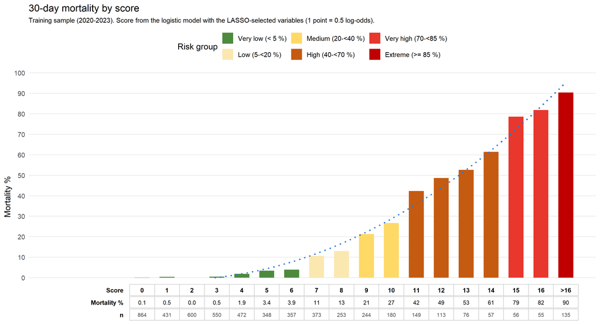

```r
plot_score_mortality(training_score_table, "Training sample (2020-2023)")
```

## Risk groups (derivation sample)

```r
risk_group_fill <- c(
  "Very low" = "#A9D18E", "Low" = "#FFF2CC", "Medium" = "#FFD966",
  "High" = "#BF9000", "Very high" = "#FF0000", "Extreme" = "#FF0000"
)

# One row per risk group, for the derivation (training) sample.
risk_group_summary <- function(score_table) {
  d <- merge(
    data.frame(score = score_range, group = score_group[as.character(score_range)]),
    score_table, by = "score", all.x = TRUE
  )
  d$n[is.na(d$n)] <- 0
  d$deaths[is.na(d$deaths)] <- 0
  groups <- levels(droplevels(d$group))
  rows <- lapply(groups, function(g) {
    x <- d[d$group == g, ]
    seen <- x[x$n > 0, ]
    data.frame(
      group = g,
      points_min = min(x$score), points_max = max(x$score),
      n = sum(x$n), deaths = sum(x$deaths),
      risk_min = min(seen$mortality), risk_max = max(seen$mortality)
    )
  })
  out <- do.call(rbind, rows)
  out$pooled <- 100 * out$deaths / out$n
  out
}

# Table in the style of the RETRASCORE risk-group table (Points, % risk, Groups)
plot_risk_table <- function(score_table, model_label, show_title = TRUE,
                            fixed_ends = FALSE) {
  s <- risk_group_summary(score_table)
  k <- nrow(s)
  fmt <- function(x) ifelse(x < 10, sprintf("%.1f", x), sprintf("%.0f", x))
  s$points_label <- ifelse(
    s$points_min == s$points_max, s$points_min,
    paste(s$points_min, "-", s$points_max)
  )
  if (k > 1) {
    s$points_label[1] <- paste("<", s$points_min[2])
    s$points_label[k] <- paste(">", s$points_max[k - 1])
  }
  s$risk_label <- ifelse(
    s$risk_min == s$risk_max, paste0(fmt(s$risk_min), " %"),
    paste0(fmt(s$risk_min), " - ", fmt(s$risk_max), " %")
  )
  if (fixed_ends) {
    s$risk_label[1] <- "< 5 %"
    s$risk_label[k] <- "> 85 %"
  }
  s$group_name <- toupper(sub(" \\(.*$", "", s$group))
  s$fill <- risk_group_fill[sub(" \\(.*$", "", s$group)]
  s$row <- k - seq_len(k)          # first group at the top

  col_x <- c(0, 1.4, 3.2, 5.2)
  cells <- rbind(
    data.frame(col = 1, row = k, label = "POINTS", fill = "white", bold = TRUE),
    data.frame(col = 2, row = k, label = "% RISK", fill = "white", bold = TRUE),
    data.frame(col = 3, row = k, label = "GROUPS", fill = "white", bold = TRUE),
    data.frame(col = 1, row = s$row, label = s$points_label, fill = "white", bold = TRUE),
    data.frame(col = 2, row = s$row, label = s$risk_label, fill = s$fill, bold = FALSE),
    data.frame(col = 3, row = s$row, label = s$group_name, fill = "white", bold = FALSE)
  )
  cells$xmin <- col_x[cells$col]
  cells$xmax <- col_x[cells$col + 1]

  title_labs <- if (show_title) {
    labs(
      title = "Risk groups of the score (derivation sample, 2020-2023)",
      subtitle = paste0("Score from the logistic model with ", model_label,
                        ".\n% risk = range of the observed 30-day mortality",
                        " of the score values in each group.")
    )
  } else {
    NULL
  }

  ggplot(cells) +
    geom_rect(aes(xmin = xmin, xmax = xmax, ymin = row, ymax = row + 1,
                  fill = fill), colour = "black", linewidth = 0.8) +
    geom_text(aes(x = (xmin + xmax) / 2, y = row + 0.5, label = label,
                  fontface = ifelse(bold, "bold", "plain")), size = 6) +
    scale_fill_identity() +
    title_labs +
    coord_cartesian(clip = "off") +
    theme_void(base_size = 12) +
    theme(plot.subtitle = element_text(size = 9), plot.margin = margin(8, 12, 8, 12))
}
```

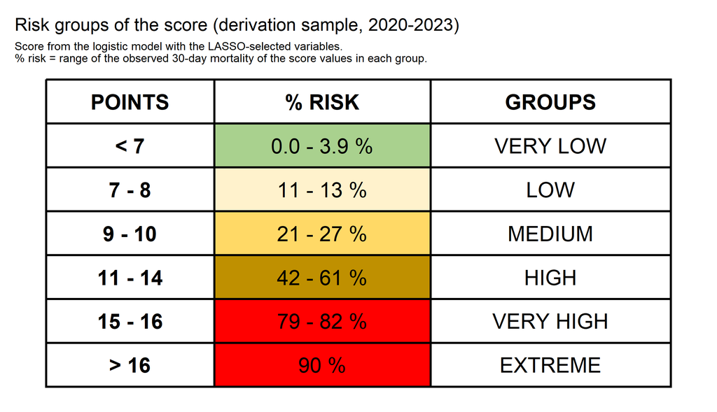

Derivation sample (2020-2023): patients and 30-day mortality in each risk group

| Group | Points | n patients | Deaths | Observed mortality (%) |
| --- | --- | --- | --- | --- |
| Very low (< 5 %) | 0 - 6 | 3622 | 41 | 1.1 |
| Low (5-<20 %) | 7 - 8 | 626 | 73 | 11.7 |
| Medium (20-<40 %) | 9 - 10 | 424 | 100 | 23.6 |
| High (40-<70 %) | 11 - 14 | 395 | 193 | 48.9 |
| Very high (70-<85 %) | 15 - 16 | 111 | 89 | 80.2 |
| Extreme (>= 85 %) | 17 | 135 | 122 | 90.4 |

```r
plot_risk_table(training_score_table, "the LASSO-selected variables")
```

## Validation sample (2024-2025)

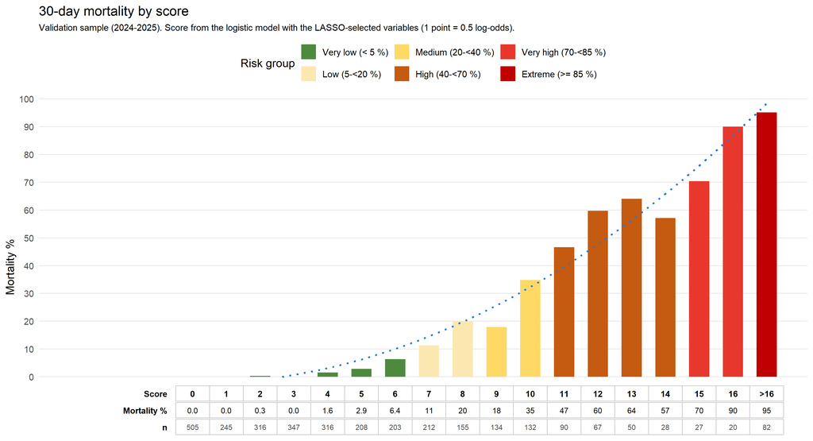

```r
plot_score_mortality(validation_score_table, "Validation sample (2024-2025)")
```

# Mortality by score: same model without the external MAIS

Same analysis as above, but the logistic model is refitted without `external_mais_group` (the remaining variables selected by the first LASSO are kept). The points are recalculated from the new coefficients with the same rule (1 point = `log_odds_per_point` log-odds, rounded, at least 1 point per term), and the risk-group colours are again defined from the observed mortality of the training sample.

```r
no_external_predictors <- setdiff(lasso_selected_predictors, "external_mais_group")

score_model <- glm(
  formula = reformulate(no_external_predictors, response = outcome_variable),
  data = selection_training_data,
  family = binomial(link = "logit"),
  na.action = na.fail
)
if (!isTRUE(score_model$converged) || anyNA(coef(score_model))) {
  stop("The logistic model without the external MAIS is not estimable.")
}

score_coefficients <- coef(score_model)[-1]
score_points <- sign(score_coefficients) *
  pmax(1, round(abs(score_coefficients) / log_odds_per_point))

score_points_table <- data.frame(
  Term = names(score_points),
  Coefficient = round(unname(score_coefficients), 3),
  Points = unname(score_points),
  row.names = NULL
)
knitr::kable(
  score_points_table,
  align = c("l", "r", "r"),
  caption = paste0(
    "Points of the score derived from the logistic model with the ",
    "LASSO-selected variables except the external MAIS (1 point = ",
    log_odds_per_point, " log-odds)"
  )
)
```

Points of the score derived from the logistic model with the LASSO-selected variables except the external MAIS (1 point = 0.5 log-odds)

| Term | Coefficient | Points |
| --- | --- | --- |
| age_category50-65 | 0.896 | 2 |
| age_category66-75 | 1.612 | 3 |
| age_category>75 | 2.321 | 5 |
| preinjury_antithrombotic | 0.683 | 1 |
| prehospital_intubation | 0.393 | 1 |
| high_risk_mechanism | 0.301 | 1 |
| pupilsmidriasis unilateral | 1.040 | 2 |
| pupilsmidriasis bilateral | 3.472 | 7 |
| gcs_le_8 | 0.776 | 2 |
| hemodynamic_failure | 1.048 | 2 |
| respiratory_failure | 0.731 | 1 |
| coagulopathy_24h | 0.522 | 1 |
| mechanical_ventilation | 0.250 | 1 |
| massive_hemorrhage | 0.997 | 2 |
| head_mais_groupYes | 1.399 | 3 |

```r
training_score_table <- score_by_value(selection_training_data)
validation_score_table <- score_by_value(selection_test_data)

score_range <- seq(
  min(training_score_table$score, validation_score_table$score),
  score_cap_high
)
training_rate <- training_score_table$mortality[
  match(score_range, training_score_table$score)
]
training_rate[is.na(training_rate)] <- 0
training_rate <- cummax(training_rate)
score_group <- cut(
  training_rate, breaks = c(-Inf, 5, 20, 40, 70, 85, Inf), right = FALSE,
  labels = risk_group_labels
)
names(score_group) <- score_range

model_label_no_external <- "the LASSO-selected variables except the external MAIS"
```

## Training sample (2020-2023), without external MAIS

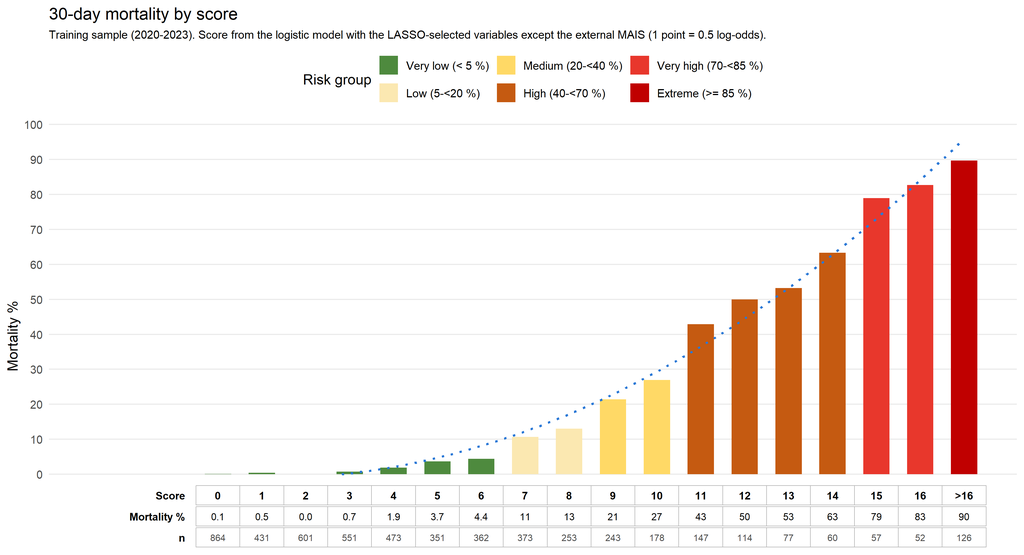

```r
plot_score_mortality(
  training_score_table, "Training sample (2020-2023)",
  model_label = model_label_no_external, left_expand = 3.1
)
```

## Risk groups (derivation sample), without external MAIS

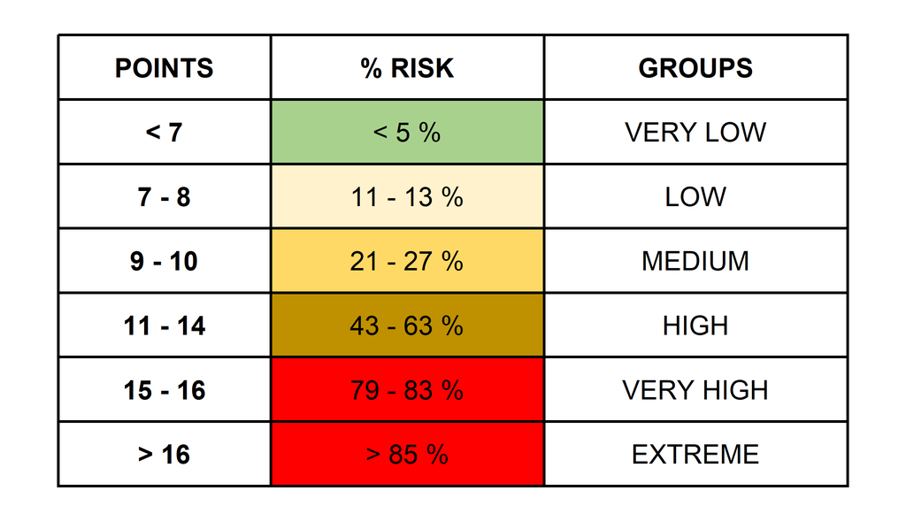

Derivation sample (2020-2023), without external MAIS: patients and 30-day mortality in each risk group

| Group | Points | n patients | Deaths | Observed mortality (%) |
| --- | --- | --- | --- | --- |
| Very low (< 5 %) | 0 - 6 | 3633 | 45 | 1.2 |
| Low (5-<20 %) | 7 - 8 | 626 | 73 | 11.7 |
| Medium (20-<40 %) | 9 - 10 | 421 | 100 | 23.8 |
| High (40-<70 %) | 11 - 14 | 398 | 199 | 50.0 |
| Very high (70-<85 %) | 15 - 16 | 109 | 88 | 80.7 |
| Extreme (>= 85 %) | 17 | 126 | 113 | 89.7 |

```r
# Final table only: extreme risk is strictly > 85 % (a rate of exactly 85 %
# stays in "Very high"), and no title/subtitle. score_group is restored after
# the table so the validation plot below keeps the original bands.
score_group_original <- score_group
score_group[training_rate == 85] <- risk_group_labels[5]
plot_risk_table(training_score_table, model_label_no_external, show_title = FALSE,
                fixed_ends = TRUE)
```

## Validation sample (2024-2025), without external MAIS

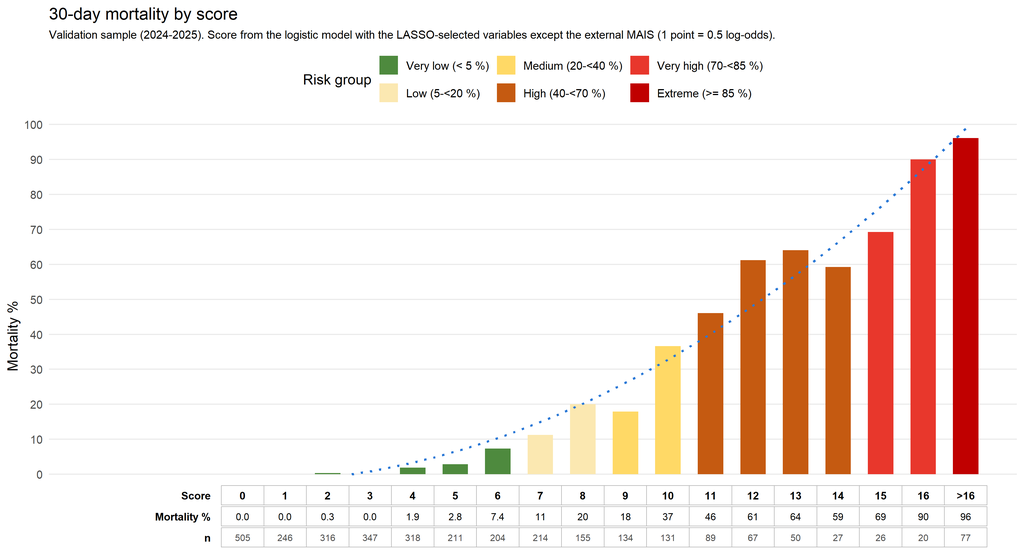

```r
plot_score_mortality(
  validation_score_table, "Validation sample (2024-2025)",
  model_label = model_label_no_external
)
```